# Když prediktor není číslo

Od rozdílu průměrů k analýze rozptylu

Publikováno

6. srpna 2026

Upraveno

5. listopadu 2026

## 1 Úvod

**QuestionHlavní biologická otázka**

**Liší se průměrnáSoučet hodnot vydělený jejich počtem; nejběžnější míra polohy (střední hodnoty). hmotnost těla mezi druhy tučňáků?**

V předchozí lekci jsme převáděli biologické tvrzení na nulovou hypotézuVýchozí předpoklad, který testujeme - typicky ‘efekt je nulový’ nebo ‘skupiny se neliší’; p-hodnota udává pravděpodobnost dat alespoň tak extrémních jako naše za předpokladu platnosti H₀. o koeficientu známého modelu. PrediktoremProměnná, pomocí níž vysvětlujeme variabilitu odezvy; v notaci y ~ x je prediktor x. byla numerická proměnnáProměnná, jejíž hodnoty jsou čísla se smysluplnou velikostí nebo rozdílem; může být diskrétní, například počet, nebo spojitá, například délka. (zeměpisná šířka) a otázka zněla, zda je sklonParametr lineárního modelu udávající, o kolik se v průměru liší odezva dvou pozorování, jejichž prediktor se liší o jednu jednotku (při stejných hodnotách ostatních prediktorů). slučitelný s nulou. V této lekci bude prediktorem kategoriální proměnnáProměnná nabývající hodnot z omezeného počtu kategorií; může být nominální (bez pořadí) nebo ordinální (s pořadím).: druh tučňáka.

Způsob uvažování zůstává stejný. Výsledek začíná jednotlivými pozorovánímiJeden zaznamenaný případ v datech, který obsahuje hodnoty jedné nebo více proměnných., pokračuje rozdílem v gramech a jeho nejistotouRozsah, v němž nevíme přesnou hodnotu parametru kvůli omezenému výběru a výběrové variabilitě; kvantifikuje se pomocí standardních chyb a intervalů spolehlivosti. a testová otázka jej pouze doplňuje.

## 2 Výsledky učení

Po prostudování této lekce dokážete:

- fitovat `lm(y ~ skupina)` pro dvě i více skupin a přečíst jeho koeficienty;
- interpretovat interceptParametr modelu: odhadnutá hodnota odezvy, když jsou všechny numerické prediktory rovny nule a kategoriální prediktory jsou v referenční skupině; geometricky jde o úsek na ose y. jako průměrSoučet hodnot vydělený jejich počtem; nejběžnější míra polohy (střední hodnoty). referenční skupinyÚroveň kategoriálního prediktoru, vůči které model vyjadřuje rozdíly ostatních skupin; její průměr (při nulových numerických prediktorech) je intercept. a ostatní koeficienty jako rozdíly vůči této skupině;
- vysvětlit dvouvýběrový t-testTest založený na t-statistice (odhad dělený standardní chybou); nejčastěji porovnává průměry dvou skupin nebo testuje, zda je koeficient modelu nulový. a analýzu rozptylu (ANOVA)Statistický test porovnávající průměry tří a více skupin zároveň; testuje, zda se alespoň jedna skupina průměrem liší od ostatních. jako otázky položené lineárnímu modeluStatistický model, v němž je průměrná odezva součtem interceptu a prediktorů násobených koeficienty; lineární je v koeficientech, takže nemusí jít jen o přímku.;
- rozlišit celkový F-test od post-hoc porovnáníPárová porovnání skupin, která společně vyhodnotí celou rodinu otázek typu ‘liší se skupina A od B?’ a upraví p-hodnoty i intervaly pro mnohonásobné porovnávání. dvojic a rozhodnout, kdy párová porovnání dávají smysl;
- napsat závěr v biologicky smysluplných jednotkách: rozdíl, jeho nejistotaRozsah, v němž nevíme přesnou hodnotu parametru kvůli omezenému výběru a výběrové variabilitě; kvantifikuje se pomocí standardních chyb a intervalů spolehlivosti., test a omezení studie.

## 3 Data: jeden řádek je jeden změřený tučňák

Tučňáky už známe z předchozích lekcí. Data obsahují tělesná měření dospělých tučňáků tří druhů z Palmerova souostroví v Antarktidě. Jeden řádek představuje jednoho změřeného jedince. Naše odezvaProměnná, jejíž variabilitu se snažíme vysvětlit nebo předpovědět; v notaci modelu y ~ x je odezva y. je hmotnost těla v gramech a kategoriálním prediktoremProměnná nabývající hodnot z omezeného počtu kategorií; může být nominální (bez pořadí) nebo ordinální (s pořadím). je druh.

Stejně jako v lekci o vztazích dvou proměnnýchVlastnost zaznamenaná u pozorování, která může mezi pozorováními nabývat různých hodnot, například druh, délka nebo počet. budeme tučňáka kroužkového (Adélie) zobrazovat oranžově, tučňáka uzdičkového (Chinstrap) fialově a tučňáka oslího (Gentoo) modrozeleně.

Tabulku načteme a známými funkcemi zjistíme, jaké hodnoty a datové typy obsahuje. `str()` ukáže strukturu tabulky a typ každé proměnné, `summary()` základní souhrny sloupců a `colSums(is.na())` počet chybějících hodnot v každém sloupci.

```r
# Načteme připravenou tabulku s jedním řádkem na tučňáka
data_tucnaci <-
  read.csv(
    file = "data/palmer_penguins.csv",
    na.strings = c("", "NA")
  )

# Zkontrolujeme strukturu a datové typy
str(object = data_tucnaci)
```

```
'data.frame':   344 obs. of  8 variables:
 $ druh             : chr  "Adelie" "Adelie" "Adelie" "Adelie" ...
 $ ostrov           : chr  "Torgersen" "Torgersen" "Torgersen" "Torgersen" ...
 $ delka_zobaku_mm  : num  39.1 39.5 40.3 NA 36.7 39.3 38.9 39.2 34.1 42 ...
 $ hloubka_zobaku_mm: num  18.7 17.4 18 NA 19.3 20.6 17.8 19.6 18.1 20.2 ...
 $ delka_kridla_mm  : int  181 186 195 NA 193 190 181 195 193 190 ...
 $ hmotnost_tela_g  : int  3750 3800 3250 NA 3450 3650 3625 4675 3475 4250 ...
 $ pohlavi          : chr  "male" "female" "female" NA ...
 $ rok              : int  2007 2007 2007 2007 2007 2007 2007 2007 2007 2007 ...
```

```r
# Prohlédneme si souhrny hodnot
summary(object = data_tucnaci)
```

```
     druh              ostrov          delka_zobaku_mm hloubka_zobaku_mm
 Length:344         Length:344         Min.   :32.10   Min.   :13.10
 Class :character   Class :character   1st Qu.:39.23   1st Qu.:15.60
 Mode  :character   Mode  :character   Median :44.45   Median :17.30
                                       Mean   :43.92   Mean   :17.15
                                       3rd Qu.:48.50   3rd Qu.:18.70
                                       Max.   :59.60   Max.   :21.50
                                       NA's   :2       NA's   :2
 delka_kridla_mm hmotnost_tela_g   pohlavi               rok
 Min.   :172.0   Min.   :2700    Length:344         Min.   :2007
 1st Qu.:190.0   1st Qu.:3550    Class :character   1st Qu.:2007
 Median :197.0   Median :4050    Mode  :character   Median :2008
 Mean   :200.9   Mean   :4202                       Mean   :2008
 3rd Qu.:213.0   3rd Qu.:4750                       3rd Qu.:2009
 Max.   :231.0   Max.   :6300                       Max.   :2009
 NA's   :2       NA's   :2
```

```r
# Spočítáme chybějící hodnoty v každém sloupci
colSums(x = is.na(x = data_tucnaci))
```

```
             druh            ostrov   delka_zobaku_mm hloubka_zobaku_mm
                0                 0                 2                 2
  delka_kridla_mm   hmotnost_tela_g           pohlavi               rok
                2                 2                11                 0
```

Tabulka má 344 řádků. Sloupec `druh` je zatím text (`chr`) a u 2 tučňáků chybí hmotnost. Hmotnost se pohybuje od 2 700 do 6 300 g, což jsou u dospělých tučňáků těchto druhů věrohodné hodnoty.

Model hmotnosti nemůže použít řádek, ve kterém hmotnost chybí: bez naměřené odezvy nelze spočítat residuumRozdíl mezi pozorovanou hodnotou odezvy a hodnotou odhadnutou modelem: eᵢ = yᵢ − ŷᵢ.. Ponecháme proto jen tučňáky se změřenou hmotností. Ostatní chybějící položky (například pohlaví) zatím nevadí, protože je v modelu nepoužíváme. Sloupec `druh` zároveň převedeme na **faktor**, tedy kategoriální proměnnou s pevným seznamem možných hodnot, kterým říkáme **úrovněJedna z kategorií kategoriální proměnné uložené v R jako faktor, například jeden druh z proměnné druh.**. Druhy žádné přirozené pořadí nemají a převod na faktor jim žádné nedává. Úrovně zadáme v určitém pořadí jen proto, že první z nich později rozhodne, vůči kterému druhu R zapíše koeficienty.

```r
# Ponecháme jen tučňáky se změřenou hmotností
data_tucnaci <-
  data_tucnaci[
    !is.na(data_tucnaci$hmotnost_tela_g),
  ]

# Druh převedeme na faktor a určíme, která úroveň bude první
data_tucnaci$druh <-
  factor(
    x = data_tucnaci$druh,
    levels = c("Adelie", "Chinstrap", "Gentoo")
  )

# Ověříme počet ponechaných řádků a úrovně druhu
nrow(x = data_tucnaci)
```

```
[1] 342
```

```r
levels(x = data_tucnaci$druh)
```

```
[1] "Adelie"    "Chinstrap" "Gentoo"
```

Prvních šest řádků připravené tabulky.

[output not shown]

**TipDoplňující: získání a příprava dat**

Pro průchod lekcí stačí připravený soubor `data/palmer_penguins.csv`. Ten záměrně zachovává všech 344 řádků, aby byly chybějící hodnoty při prvním prohlédnutí viditelné. Pokud si ale chcete celý postup zopakovat, následující kód provede celý sled kroků: **získá data → vybere a přejmenuje sloupce → připraví je pro model hmotnosti → uloží vlastní pracovní kopii**.

Kód vynechá řádky bez hmotnosti hned po stažení, takže vlastní kopie bude mít jen 342 řádků. Druh v ní rovnou uloží jako faktor se stejným pořadím úrovní jako výše. Tento blok můžete přeskočit; další příklady používají tabulku `data_tucnaci` připravenou výše.

```r
# Tento příkaz stačí spustit pouze jednou
# install.packages("palmerpenguins")

# Získáme data a prohlédneme chybějící hmotnosti
data_puvodni <- palmerpenguins::penguins
sum(is.na(data_puvodni$body_mass_g))
data_puvodni <- data_puvodni[!is.na(data_puvodni$body_mass_g), ]

# Vybereme, přejmenujeme a upravíme sloupce pro lekci
data_tucnaci <-
  data.frame(
    druh = factor(
      x = data_puvodni$species,
      levels = c("Adelie", "Chinstrap", "Gentoo")
    ),
    ostrov = as.character(data_puvodni$island),
    delka_zobaku_mm = data_puvodni$bill_length_mm,
    hloubka_zobaku_mm = data_puvodni$bill_depth_mm,
    delka_kridla_mm = data_puvodni$flipper_length_mm,
    hmotnost_tela_g = data_puvodni$body_mass_g,
    pohlavi = as.character(data_puvodni$sex),
    rok = data_puvodni$year
  )

# Uložíme si zpracovanou tabulku pro další práci
write.csv(
  x = data_tucnaci,
  file = "data/palmer_penguins_vlastni_kopie.csv",
  row.names = FALSE,
  na = ""
)
```

Balíček `palmerpenguins` obsahuje kopii původních tabulek z Environmental Data Initiative. [Dokumentace balíčku palmerpenguins](https://allisonhorst.github.io/palmerpenguins/articles/download.html) uvádí také cestu k neupraveným archivním souborům. Měření pocházejí z výzkumu tučňáků rodu *Pygoscelis* v letech 2007–2009. Data shromáždila Kristen Gorman ve spolupráci s Palmer Station Long Term Ecological Research a byla zveřejněna pod licencí CC0. Připravený soubor a jeho přesná provenance jsou popsány v `data/README.md`; biologickou studii uvádějí Gorman, Williams a Fraser (2014), DOI: 10.1371/journal.pone.0090081.

## 4 Hmotnosti tučňáků kroužkových a oslích

Pro první srovnání ponecháme jen dva druhy: tučňáka kroužkového (Adélie) a tučňáka oslího (Gentoo). V prvním grafu jsou jejich hmotnosti smíchané dohromady. Každý bod představuje jedno pozorováníJeden zaznamenaný případ v datech, který obsahuje hodnoty jedné nebo více proměnných., tedy jednoho změřeného jedince.

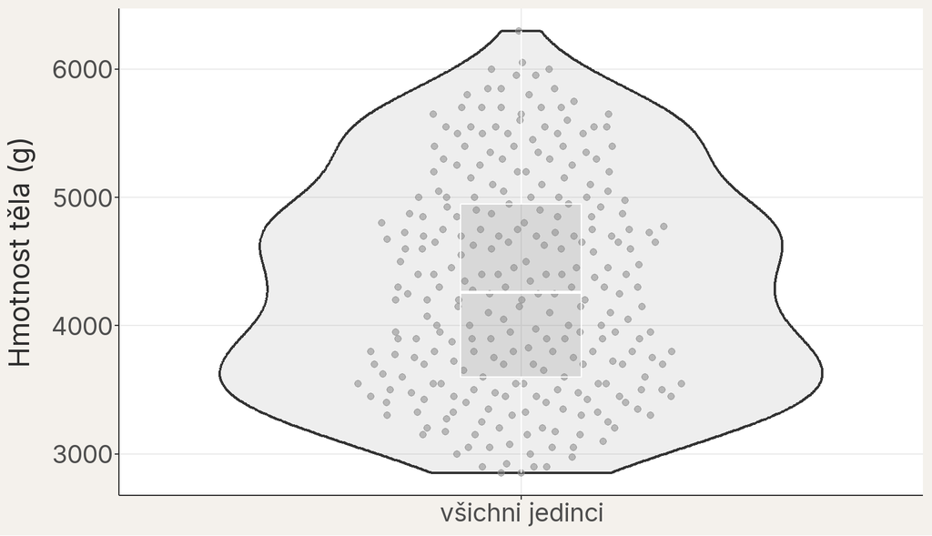

Hmotnosti tučňáků dvou druhů předtím, než použijeme informaci o druhu. Všechny body jsou záměrně šedé. Krabicový graf (boxplot) uprostřed ukazuje medián a kvartily.

Bez další proměnnéVlastnost zaznamenaná u pozorování, která může mezi pozorováními nabývat různých hodnot, například druh, délka nebo počet. umíme popsat jen tento společný soubor. V lekci o popisu jedné proměnné jsme k tomu používali počet pozorování, minimum, maximum, průměrSoučet hodnot vydělený jejich počtem; nejběžnější míra polohy (střední hodnoty)., mediánHodnota rozdělující seřazená data na dvě stejně početné poloviny; 50% kvantil (prostřední kvartil). a mezikvartilové rozpětí (IQR)Rozdíl mezi 3. kvartilem (Q3) a 1. kvartilem (Q1); pokrývá prostředních 50 % dat a je robustní vůči odlehlým pozorováním.. Stejné souhrny nyní spočítáme v R:

```r
# Pro první pohled vybereme dva druhy, ale zatím je nesrovnáváme
data_dva_druhy <-
  data_tucnaci[
    data_tucnaci$druh %in% c("Adelie", "Gentoo"),
  ]
data_dva_druhy$druh <- droplevels(x = data_dva_druhy$druh)

# Připomeneme si známé souhrny pro všechny hmotnosti dohromady
c(
  pocet = length(x = data_dva_druhy$hmotnost_tela_g),
  prumer = mean(x = data_dva_druhy$hmotnost_tela_g),
  median = median(x = data_dva_druhy$hmotnost_tela_g),
  minimum = min(data_dva_druhy$hmotnost_tela_g),
  maximum = max(data_dva_druhy$hmotnost_tela_g),
  IQR = IQR(x = data_dva_druhy$hmotnost_tela_g)
)
```

```
   pocet   prumer   median  minimum  maximum      IQR
 274.000 4318.066 4262.500 2850.000 6300.000 1350.000
```

Společný průměr 4 318,1 g shrnuje střed šedého oblaku, ale zakrývá možnost, že se v něm mísí odlišné skupiny. Tuto možnost prověří proměnná `druh`.

Proměnná `druh` je kategoriálníProměnná nabývající hodnot z omezeného počtu kategorií; může být nominální (bez pořadí) nebo ordinální (s pořadím).: její hodnoty nejsou měření na číselné škále, ale názvy kategorií. Funkce `table()` ukáže, kolik řádků (jedinců) patří do každé kategorie:

```r
table(data_tucnaci$druh)
```

```
   Adelie Chinstrap    Gentoo
      151        68       123
```

V celé tabulce jsou tři druhy. Pro první model ponecháváme pouze Adélie a Gentoo, které jsme vybrali do objektu `data_dva_druhy`.

**QuestionCo by tvrdila nulová hypotéza?**

V předchozí lekci jsme testovali nulovou hypotézuVýchozí předpoklad, který testujeme - typicky ‘efekt je nulový’ nebo ‘skupiny se neliší’; p-hodnota udává pravděpodobnost dat alespoň tak extrémních jako naše za předpokladu platnosti H₀. o koeficientu modelu. Zkuste vyslovit nulovou hypotézu pro průměrnou hmotnost Adélie a Gentoo. Jak by podle ní vypadal graf, ve kterém body obarvíme podle druhu?

**DůležitéMožná odpověď**

Nulová hypotéza tvrdí, že průměrná hmotnost obou druhů je v širší populaciCelá množina jednotek nebo širší proces, o kterém chceme pomocí výběru něco zjistit; její vlastnosti (parametry) obvykle neznáme. stejná: rozdíl průměrů je 0 g. Body obou druhů by pak ležely kolem stejné výšky. Jednotlivci by se stále lišili, ale žádný druh by systematicky neležel výše.

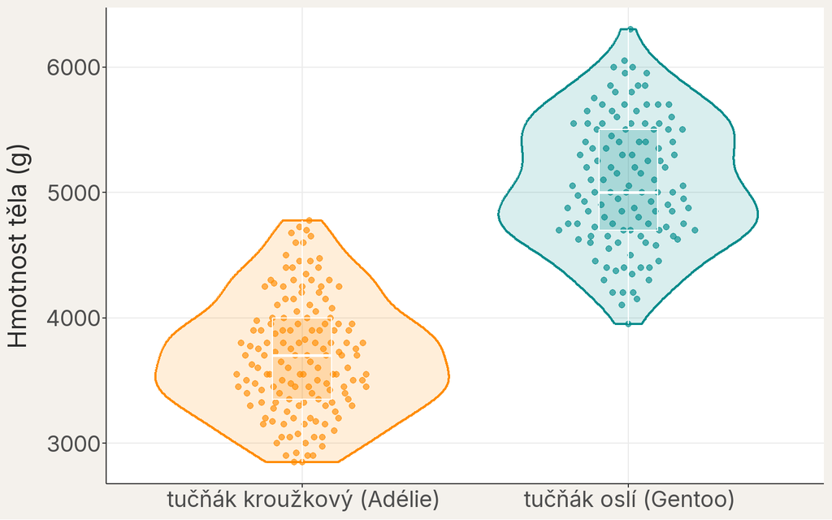

Stejná měření po přidání kategoriální proměnné druh. Barva i vodorovná poloha nyní ukazují příslušnost ke skupině a každý druh má vlastní krabicový graf.

Po rozdělení vidíme silný posun: body tučňáků oslích leží převážně výše. Zároveň se hodnoty uvnitř každého druhu liší a oba soubory se částečně překrývají. Druh nám tedy pomohl odhalit strukturu, kterou šedý graf skrýval.

### 4.1 Průměr a směrodatná odchylka každého druhu

Počet pozorování, průměr a směrodatná odchylka hmotnosti ve dvou skupinách.

| Druh | Počet jedinců | Průměr (g) | SD (g) |
| --- | --- | --- | --- |
| tučňák kroužkový (Adélie) | 151 | 3700,7 | 458,6 |
| tučňák oslí (Gentoo) | 123 | 5076,0 | 504,1 |

Průměr shrnuje polohu jedné skupiny, ale neříká, jak se liší jednotlivci uvnitř ní. Proto vedle něj zobrazíme směrodatnou odchylkuOdmocnina rozptylu; vyjadřuje typickou vzdálenost hodnot od průměru ve stejných jednotkách jako původní data. (SD) i všechny body. Svislá úsečka kolem průměru sahá od průměru minus jedna SD po průměr plus jedna SD.

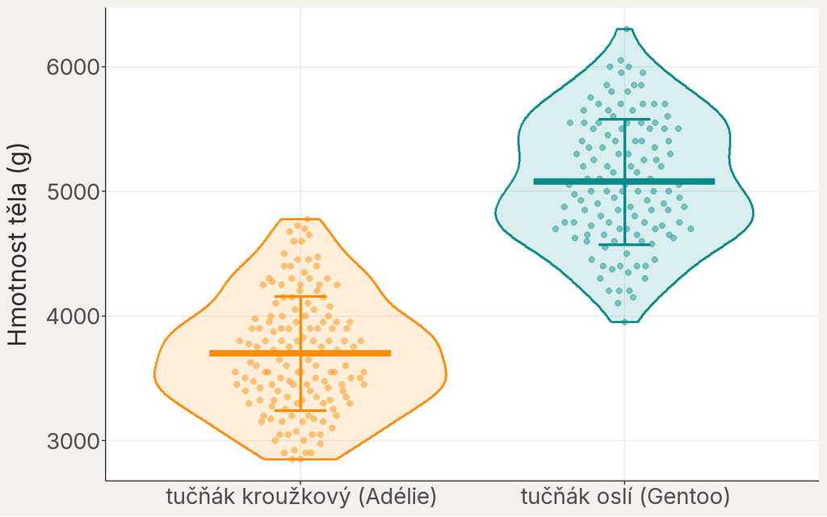

Body jsou jednotliví tučňáci, silné vodorovné úsečky jsou průměry a tenké svislé úsečky ukazují průměr ± 1 SD.

Průměr tučňáků oslích je o 1 375,4 g vyšší než průměr tučňáků kroužkových. To je hlavní věcný rozdíl, který bude náš model popisovat.

## 5 Rozdíl průměrů

Dva průměrySoučet hodnot vydělený jejich počtem; nejběžnější míra polohy (střední hodnoty). se mohou lišit o stejnou hodnotu, ale síla informace závisí také na variabilitěObecný termín pro rozsah, v němž se hodnoty proměnné liší od sebe navzájem; kvantifikuje se pomocí rozptylu, SD, IQR nebo rozsahu. uvnitř skupin. Následující graf proto skrývá jednotlivé body a ponechává pouze tři součásti: dva průměry, jejich rozdíl a SDOdmocnina rozptylu; vyjadřuje typickou vzdálenost hodnot od průměru ve stejných jednotkách jako původní data. každé skupiny.

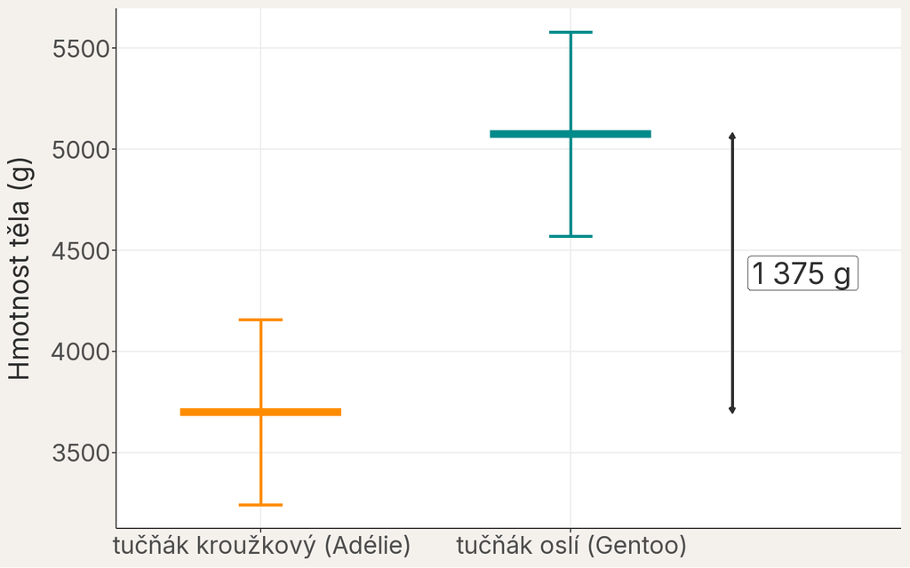

Silné vodorovné úsečky jsou průměry, svislé úsečky ukazují ± 1 SD a závorka vpravo měří rozdíl mezi průměry. Celkový rozsah dat zde záměrně nezobrazujeme.

Svislá závorka měří systematický rozdíl, který chceme vysvětlit druhem. Úsečky SD připomínají, že každý průměr zastupuje celý oblak různých jedinců. Rozdíl průměrů proto nikdy nebudeme číst bez informace o variabilitě kolem nich.

### 5.1 Stejný rozdíl, jiná variabilita

Následující obrázek není další výběrSoubor pozorování, z něhož počítáme statistiky a pomocí něhož se snažíme popsat širší populaci nebo proces. tučňáků. Je to záměrně zjednodušený myšlenkový pokus se dvěma vymyšlenými skupinami A a B po deseti jedincích. Ve všech třech panelech se průměry skupin liší o stejných 1 000 g; panely se liší jen tím, jak daleko jsou jedinci rozptýleni kolem průměru své skupiny.

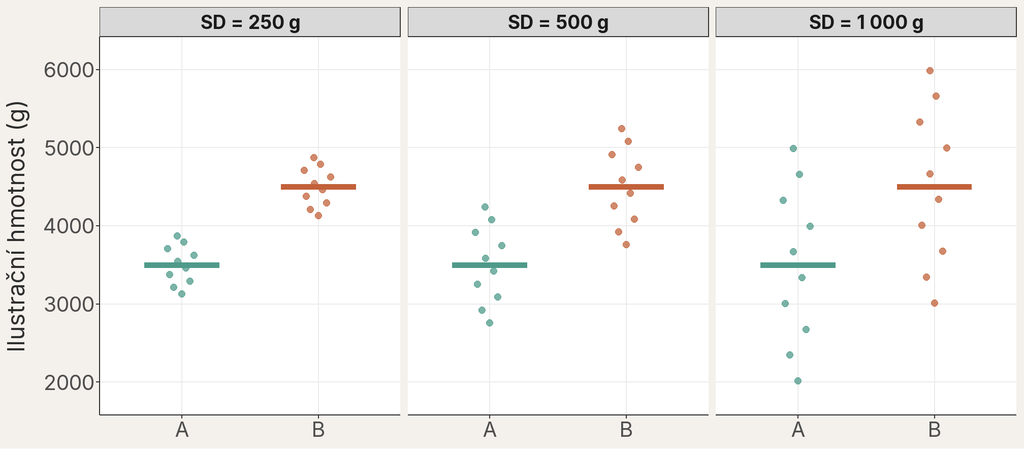

Myšlenkový pokus se dvěma vymyšlenými skupinami A a B: rozdíl mezi průměry (vodorovné úsečky) je ve všech třech panelech stejný, směrodatná odchylka uvnitř skupin zleva doprava roste.

**QuestionKde je rozdíl nejpřesvědčivější?**

Rozdíl průměrů je ve všech panelech stejný. Ve kterém panelu bychom nejsnáze odlišili systematický rozdíl mezi skupinami od běžných rozdílů mezi jedinci? A ve kterém nejhůře?

**DůležitéMožná odpověď**

Nejsnáze v levém panelu: skupiny se téměř nepřekrývají a rozdíl průměrů je mnohem větší než typická odchylka jedince od průměru jeho skupiny. Nejhůře v pravém panelu: rozdíl průměrů je zde stejně velký jako směrodatná odchylka uvnitř skupin a skupiny se výrazně překrývají. Stejný rozdíl průměrů tak může být přesvědčivý i sotva rozeznatelný.

**Rozdíl průměrů tedy nečteme izolovaně. Posuzujeme jej vzhledem k variabilitě, která zůstává kolem skupinových průměrů.** Z tohoto porovnání vychází také název metody **analýza rozptyluStatistický test porovnávající průměry tří a více skupin zároveň; testuje, zda se alespoň jedna skupina průměrem liší od ostatních. (ANOVA)**, ke které se v této lekci dostaneme: porovnává variabilitu zachycenou rozdílnými skupinovými průměry s residuální variabilitou uvnitř skupin.

Rozdíl hmotností zatím pouze popisujeme. Abychom k němu mohli připojit nejistotu a test, **fitujeme lineární modelStatistický model, v němž je průměrná odezva součtem interceptu a prediktorů násobených koeficienty; lineární je v koeficientech, takže nemusí jít jen o přímku.**: odezvouProměnná, jejíž variabilitu se snažíme vysvětlit nebo předpovědět; v notaci modelu y ~ x je odezva y. bude hmotnost těla a prediktoremProměnná, pomocí níž vysvětlujeme variabilitu odezvy; v notaci y ~ x je prediktor x. druh. Před vložením kategoriální proměnnéProměnná nabývající hodnot z omezeného počtu kategorií; může být nominální (bez pořadí) nebo ordinální (s pořadím). do známé formule si připomeneme, jak model pracoval s numerickým prediktoremProměnná, jejíž hodnoty jsou čísla se smysluplnou velikostí nebo rozdílem; může být diskrétní, například počet, nebo spojitá, například délka..

## 6 Stejný lineární model, jiný prediktor

### 6.1 Připomenutí: přímka pro délku ploutve a hmotnost

V lekci o vztazích dvou proměnnýchVlastnost zaznamenaná u pozorování, která může mezi pozorováními nabývat různých hodnot, například druh, délka nebo počet. jsme u tučňáků kreslili bodový grafGraf vztahu dvou numerických proměnných, v němž každý bod představuje jedno pozorování a jeho dvě hodnoty určují polohu na osách. délky ploutve a tělesné hmotnosti; v lekci o lineárním modeluStatistický model, v němž je průměrná odezva součtem interceptu a prediktorů násobených koeficienty; lineární je v koeficientech, takže nemusí jít jen o přímku. jsme podobný vztah popsali přímkou. Přímku si připomeneme právě na tučňácích: délka ploutve (sloupec `delka_kridla_mm`) bude prediktoremProměnná, pomocí níž vysvětlujeme variabilitu odezvy; v notaci y ~ x je prediktor x. a hmotnost těla odezvouProměnná, jejíž variabilitu se snažíme vysvětlit nebo předpovědět; v notaci modelu y ~ x je odezva y..

Každý bod je jeden tučňák. Délka ploutve určuje jeho vodorovnou polohu a fialová přímka ukazuje odhadnutou hodnotuHodnota odezvy, kterou fitovaný model přiřadí pozorování na základě jeho hodnot prediktorů; značí se často ŷ. hmotnosti pro tuto délku.

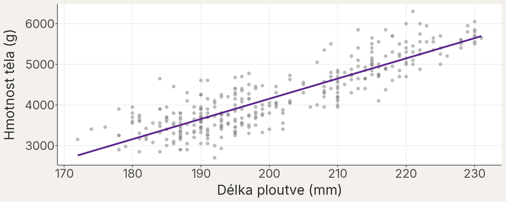

Pozorované délky ploutve a hmotnosti tučňáků s odhadnutou přímkou. Každá hodnota numerického prediktoru vybírá jedno místo na přímce.

### 6.2 Stejná věc, různé názvy

Ve statistice mívá tatáž věc často několik názvů a symbolů. Učebnice, vědecké články i statistické programy si je volí po svém. Nový zápis proto nemusí znamenat novou myšlenku a ukážeme si to hned na rovnici přímky. Slovy zní pořád stejně:

$$\text{odhadnutá hmotnost}
=
\text{intercept}
+
\text{sklon} \times \text{délka ploutve}.$$

V lekci o lineárním modelu i v lekcích o nejistotě a testování hypotéz jsme interceptParametr modelu: odhadnutá hodnota odezvy, když jsou všechny numerické prediktory rovny nule a kategoriální prediktory jsou v referenční skupině; geometricky jde o úsek na ose y. a sklonParametr lineárního modelu udávající, o kolik se v průměru liší odezva dvou pozorování, jejichž prediktor se liší o jednu jednotku (při stejných hodnotách ostatních prediktorů). psali jako $a$ a $b$:

$$\hat{y}_i = a + b \cdot x_i.$$

Od této lekce budeme tytéž koeficienty psát řeckým písmenem **$\beta$ (beta)**, jak je najdete v mnoha článcích a učebnicích:

$$\hat{y}_i = \hat{\beta}_0 + \hat{\beta}_1 \cdot x_i.$$

Přímka se nezměnila, změnil se jen její zápis: $x_i$ je délka ploutve tučňáka $i$, $\hat{y}_i$ jeho odhadnutá hmotnost, $\hat{\beta}_0$ intercept, tedy dřívější $a$, a $\hat{\beta}_1$ sklon, tedy dřívější $b$. Stříška označuje odhad z našich dat. Bez stříšky znamenají $\beta_0$ a $\beta_1$ intercept a sklon v širší populaciCelá množina jednotek nebo širší proces, o kterém chceme pomocí výběru něco zjistit; její vlastnosti (parametry) obvykle neznáme..

### 6.3 Kde je intercept?

Intercept $\hat{\beta}_0$ je odhadnutá hmotnost tučňáka s ploutví dlouhou 0 mm. Nula leží daleko mimo pozorované délky ploutví (172–231 mm), proto plnou přímku prodloužíme čárkovaně až k nule. Vychází $\hat{\beta}_0 = \text{−5 781}$ g, tedy záporná hmotnost. Intercept umíme v rovnici vypočítat, ale tady nemá biologický smysl: je to extrapolacePoužití modelu pro hodnoty prediktoru mimo rozsah pozorovaných dat; tvar vztahu tam nemáme ověřený, a predikce proto může být zavádějící. daleko za naše data.

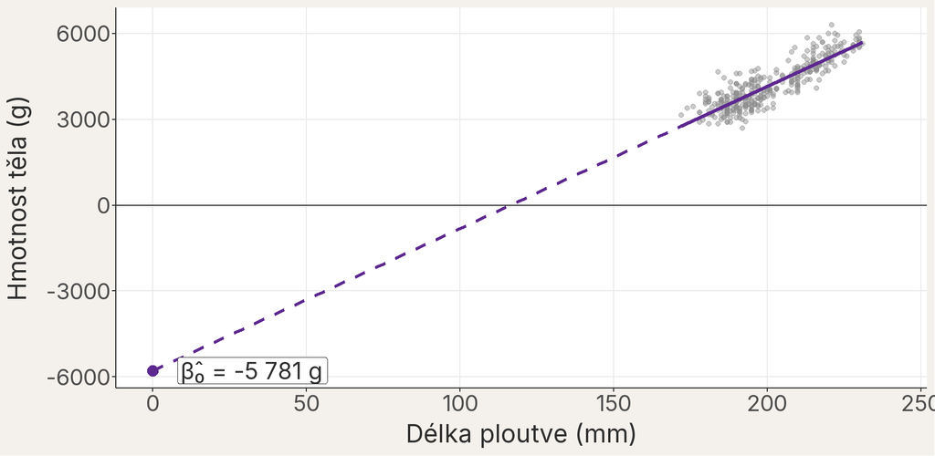

Intercept je výška přímky při hodnotě prediktoru 0. Čárkovaná část upozorňuje, že mezi nulou a nejkratší pozorovanou ploutví nemáme žádná data.

### 6.4 Kde je sklon?

Sklon $\hat{\beta}_1$ je změna odhadnuté hmotnosti při prodloužení ploutve o 1 mm. Jeden milimetr by byl v grafu téměř neviditelný, proto zvýrazníme prodloužení o 10 mm. Odpovídající změna výšky přímky je $10 \cdot \hat{\beta}_1 = \text{497}$ g. Na jeden milimetr tedy připadá $\hat{\beta}_1 = \text{497} / 10 = \text{49,7}$ g.

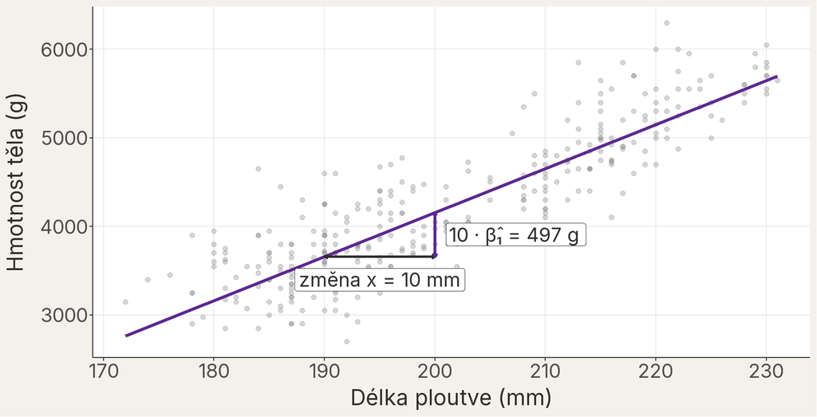

Sklon převádí změnu prediktoru na změnu odhadnuté hodnoty. Kvůli čitelnosti je zobrazena změna při prodloužení ploutve o 10 mm.

### 6.5 Kde je residuum?

ResiduumRozdíl mezi pozorovanou hodnotou odezvy a hodnotou odhadnutou modelem: eᵢ = yᵢ − ŷᵢ. je svislá vzdálenost naměřené hodnoty od hodnoty na přímce. U zvýrazněného tučňáka s ploutví dlouhou 202 mm porovnáme naměřenou hmotnost 3 400 g s odhadnutou hodnotou 4 256 g. Residuum je jejich rozdíl, -856 g.

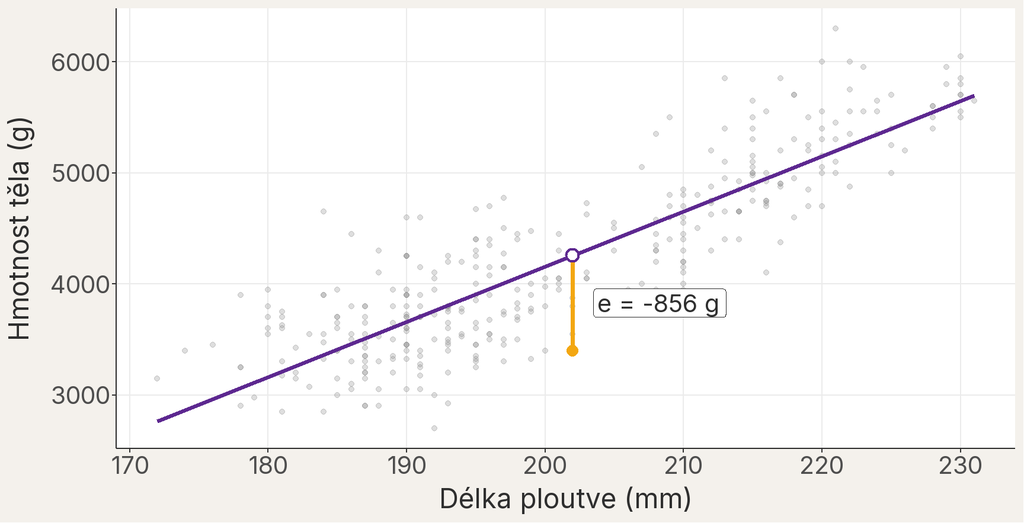

Residuum jednoho pozorování je svislá vzdálenost mezi naměřenou hodnotou (plný oranžový bod) a odhadnutou hodnotou na přímce (prázdný fialový bod).

### 6.6 Stejné koeficienty ve výstupu R

Funkce `lm()` vrátí stejné dva koeficienty, které jsme v grafech hledali odděleně.

```r
# Odhadneme přímku pro hmotnost podle délky ploutve
mod_ploutev <-
  lm(
    formula = hmotnost_tela_g ~ delka_kridla_mm,
    data = data_tucnaci
  )

# Zobrazíme odhadnutý intercept a sklon
coef(object = mod_ploutev)
```

```
    (Intercept) delka_kridla_mm
    -5780.83136        49.68557
```

Řádek `(Intercept)` je intercept, tedy výška přímky při délce ploutve 0 mm. Řádek `delka_kridla_mm` je sklon, tedy změna odhadnuté hmotnosti při prodloužení ploutve o 1 mm.

Pro tučňáka s ploutví dlouhou 190 mm:

$$\text{odhadnutá hmotnost}
=
\text{−5 780,8}
+
\text{49,69}
\cdot
190
=
\text{3 659,4}\ \text{g}.$$

Residuum dál měří svislou vzdálenost konkrétního pozorováníJeden zaznamenaný případ v datech, který obsahuje hodnoty jedné nebo více proměnných. od této přímky. U numerického prediktoru jsme tedy naměřenou hodnotu rozdělili na hodnotu odhadnutou modelem a residuum:

$$\text{naměřená hodnota}
=
\text{odhadnutá hodnota}
+
\text{residuum},$$

$$y_i = \hat{y}_i + e_i = \hat{\beta}_0 + \hat{\beta}_1 x_i + e_i.$$

Číslo $x_i$ určovalo polohu pozorování na vodorovné ose a výraz $\hat{\beta}_0 + \hat{\beta}_1 x_i$ vybral odpovídající výšku na přímce. Prediktor druh ale obsahuje názvy, ne čísla. Aby mohl vstoupit do stejného výpočtu, model si z něj vytvoří číselnou proměnnou.

## 7 Lineární model s kategoriální proměnnou

Vraťme se k hlavní biologické otázce: **liší se průměrná hmotnostSoučet hodnot vydělený jejich počtem; nejběžnější míra polohy (střední hodnoty). Adélie a Gentoo?** OdezvouProměnná, jejíž variabilitu se snažíme vysvětlit nebo předpovědět; v notaci modelu y ~ x je odezva y. je stále hmotnost těla v gramech. Místo numerické délky ploutve ale modelu předáváme název druhu.

Lineární modelStatistický model, v němž je průměrná odezva součtem interceptu a prediktorů násobených koeficienty; lineární je v koeficientech, takže nemusí jít jen o přímku. potřebuje způsob, jak dvě kategorie vložit do rovnice. Pro dva druhy stačí **binární proměnnáProměnná nabývající právě dvou hodnot, nejčastěji 0/1, přítomnost/nepřítomnost, ano/ne.** **„je Gentoo?“**: hodnota 0 znamená „ne“, tedy Adélie, a hodnota 1 znamená „ano“, tedy Gentoo. Takové proměnné se říká **indikátorová proměnná**; protože ji zapínáme a vypínáme, budeme jí říkat **přepínač**. Nejde o nové biologické měření ani pořadí druhů. Je to pouze číselný zápis příslušnosti ke skupině. Tabulka jej ukazuje jako nový sloupec vedle dvou skutečných pozorováníJeden zaznamenaný případ v datech, který obsahuje hodnoty jedné nebo více proměnných..

Dvě skutečná pozorování a číselný přepínač pro jejich skupinu.

| Druh | Naměřená hmotnost (g) | je Gentoo? |
| --- | --- | --- |
| tučňák kroužkový (Adélie) | 3750 | 0 |
| tučňák oslí (Gentoo) | 4500 | 1 |

V následujícím grafu tvoří stejná proměnná vodorovnou osu. Model stále dostává přesně hodnotu 0 nebo 1. Jednotlivé body v každé skupině pouze nepatrně posuneme doleva a doprava, aby se navzájem nepřekrývaly; tento zobrazovací posun nevytváří nové hodnoty prediktoruProměnná, pomocí níž vysvětlujeme variabilitu odezvy; v notaci y ~ x je prediktor x.. Vodorovné úsečky jsou dvě odhadnuté hodnotyHodnota odezvy, kterou fitovaný model přiřadí pozorování na základě jeho hodnot prediktorů; značí se často ŷ. a tečkované svislice jsou vzdálenosti jednotlivých měření od těchto odhadnutých hodnot. Fialová šipka označená $\hat{\beta}_1$ ukazuje rozdíl mezi oběma průměry; proč je to právě tento koeficient, si vysvětlíme hned pod grafem.

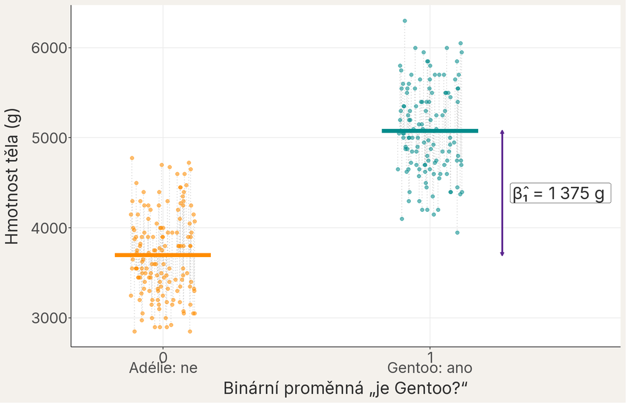

Kategorie druhu zapsaná binární proměnnou 0/1. Model přiřadí všem jedincům s hodnotou 0 průměr Adélie a všem jedincům s hodnotou 1 průměr Gentoo. Body jsou jen kvůli překryvu mírně posunuty do stran; tečkované úsečky jsou residua.

Nula a jednička nejsou další biologická měření a neříkají, že jeden druh je „vyšší“ nebo „lepší“. Jsou jen jazykem, kterým modelu sdělíme příslušnost ke skupině. Stejně jako u numerického prediktoru zůstává odhadnutá hodnota ve tvaru interceptParametr modelu: odhadnutá hodnota odezvy, když jsou všechny numerické prediktory rovny nule a kategoriální prediktory jsou v referenční skupině; geometricky jde o úsek na ose y. plus koeficient krát hodnota prediktoru.

### 7.1 Rovnice se dvěma hodnotami přepínače

**Intercept** je v tomto modelu průměrná hmotnost referenčního druhu Adélie. **Druhý koeficient** je rozdíl mezi průměrem Gentoo a průměrem Adélie. U numerického prediktoru byl druhý koeficient sklonParametr lineárního modelu udávající, o kolik se v průměru liší odezva dvou pozorování, jejichž prediktor se liší o jednu jednotku (při stejných hodnotách ostatních prediktorů).; zde má nový význam skupinového rozdílu. Slovy:

$$\begin{aligned}
\text{odhadnutá hmotnost těla}
&=
\text{průměrná hmotnost druhu Adélie} \\
&\quad +
\text{rozdíl Gentoo vůči Adélie}
\cdot
\text{„je Gentoo?“}.
\end{aligned}$$

Pro Adélie má přepínač hodnotu 0:

$$\begin{aligned}
\text{odhadnutá hmotnost Adélie}
&=
\text{3 700,7}
+
\text{1 375,4}
\cdot 0 \\
&=
\text{3 700,7}\ \text{g}.
\end{aligned}$$

Pro Gentoo má přepínač hodnotu 1:

$$\begin{aligned}
\text{odhadnutá hmotnost Gentoo}
&=
\text{3 700,7}
+
\text{1 375,4}
\cdot 1 \\
&=
\text{5 076,0}\ \text{g}.
\end{aligned}$$

Obecně zapíšeme stejný vztah se symboly, které už známe. Symbol $x_i$ je nyní přepínač „je Gentoo?“ pro tučňáka $i$ (0 nebo 1), $\hat{\beta}_0$ odhadnutý průměr Adélie a $\hat{\beta}_1$ odhadnutý rozdíl Gentoo minus Adélie. Ve výstupu R je $\hat{\beta}_0$ řádek `(Intercept)` a $\hat{\beta}_1$ řádek `druhGentoo`:

$$\hat{y}_i = \hat{\beta}_0 + \hat{\beta}_1 x_i,$$

$$y_i = \hat{\beta}_0 + \hat{\beta}_1 x_i + e_i.$$

Zápis se od numerického prediktoru nezměnil. Změnil se význam $x_i$ a tím i význam koeficientu $\hat{\beta}_1$: už nepopisuje změnu při zvýšení prediktoru o jednu měrnou jednotku, ale rozdíl jedné skupiny vůči referenční skupině.

**UpozorněníNula a jednička nejsou pořadí druhů**

Kdybychom vyměnili druh, vůči kterému model rozdíl zapisuje, změnil by se přepínač, intercept i znaménko koeficientu. Skupinové průměry a biologický obsah dat by však zůstaly stejné. Kódování je jazyk modelu, ne vlastnost tučňáků.

## 8 Dvouskupinový model v R

V R zůstává funkce `lm()` stejná. Do pravé strany formule vložíme `druh`. R ale musí rozhodnout, vůči kterému druhu bude zapisovat rozdíl. Proto zvolí jednu úroveň faktoruJedna z kategorií kategoriální proměnné uložené v R jako faktor, například jeden druh z proměnné druh. jako **referenční skupinuÚroveň kategoriálního prediktoru, vůči které model vyjadřuje rozdíly ostatních skupin; její průměr (při nulových numerických prediktorech) je intercept.**.

Ve výchozím kódování používá R jako referenční skupinu první úroveň faktoru. Při přípravě dat jsme pořadí nastavili na `Adelie`, `Chinstrap`, `Gentoo`; po ponechání dvou druhů proto zůstane první Adélie. Volba referenční skupiny je nutná, protože informace „je Adélie?“ a „je Gentoo?“ jsou u dvou druhů navzájem dokonale propojené: známe-li jednu odpověď, druhou už dopočítáme. Model proto použije jeden společný základ – interceptParametr modelu: odhadnutá hodnota odezvy, když jsou všechny numerické prediktory rovny nule a kategoriální prediktory jsou v referenční skupině; geometricky jde o úsek na ose y. referenční skupiny – a jeden rozdíl druhé skupiny vůči němu.

```r
# Ponecháme dva druhy a odstraníme nevyužitou třetí úroveň
data_dva_druhy <-
  data_tucnaci[
    data_tucnaci$druh %in% c("Adelie", "Gentoo"),
  ]
data_dva_druhy$druh <- droplevels(x = data_dva_druhy$druh)

# Zkontrolujeme pořadí úrovní; první je referenční skupina
levels(x = data_dva_druhy$druh)
```

```
[1] "Adelie" "Gentoo"
```

```r
# Fitujeme známý lineární model s kategoriálním prediktorem
mod_dva_druhy <-
  lm(
    formula = hmotnost_tela_g ~ druh,
    data = data_dva_druhy
  )

# Prohlédneme si celý známý výstup modelu
summary(object = mod_dva_druhy)
```

```
Call:
lm(formula = hmotnost_tela_g ~ druh, data = data_dva_druhy)

Residuals:
     Min       1Q   Median       3Q      Max
-1126.02  -369.50   -26.02   343.00  1223.98

Coefficients:
            Estimate Std. Error t value Pr(>|t|)
(Intercept)  3700.66      39.02   94.83   <2e-16 ***
druhGentoo   1375.35      58.24   23.61   <2e-16 ***
---
Signif. codes:  0 '***' 0.001 '**' 0.01 '*' 0.05 '.' 0.1 ' ' 1

Residual standard error: 479.5 on 272 degrees of freedom
Multiple R-squared:  0.6721,    Adjusted R-squared:  0.6709
F-statistic: 557.6 on 1 and 272 DF,  p-value: < 2.2e-16
```

V této lekci čteme z tabulky `Coefficients` koeficienty, jejich standardní chyby, t-statistiky a p-hodnoty. Spodní řádek s `Multiple R-squared` zatím necháme stranou. K řádku `F-statistic` se vrátíme v části o analýze rozptylu, kde si tento typ testu přečteme přehledněji z funkce `anova()`.

V dalším grafu bude oranžová úsečka průměrSoučet hodnot vydělený jejich počtem; nejběžnější míra polohy (střední hodnoty). Adélie a modrozelená úsečka průměr Gentoo. Proto tabulka ukazuje, kde každé číslo v grafu najdeme.

Dvouskupinové koeficienty a jejich význam.

| Řádek výstupu | Odhad (g) | Biologický význam | Kde číslo vidíme v grafu |
| --- | --- | --- | --- |
| (Intercept) | 3700,7 | průměrná hmotnost Adélie | černá šipka β̂₀ od nuly k oranžové úsečce |
| druhGentoo | 1375,4 | průměr Gentoo minus průměr Adélie | fialová šipka β̂₁ od oranžové k modrozelené úsečce |

Tabulka překládá řádky výstupu do slov a graf pod ní umisťuje stejná dvě čísla přímo k datům. Intercept je černá šipka $\hat{\beta}_0$ od nuly k oranžové úsečce. Koeficient `druhGentoo` je fialová šipka $\hat{\beta}_1$ od oranžové úsečky k modrozelené.

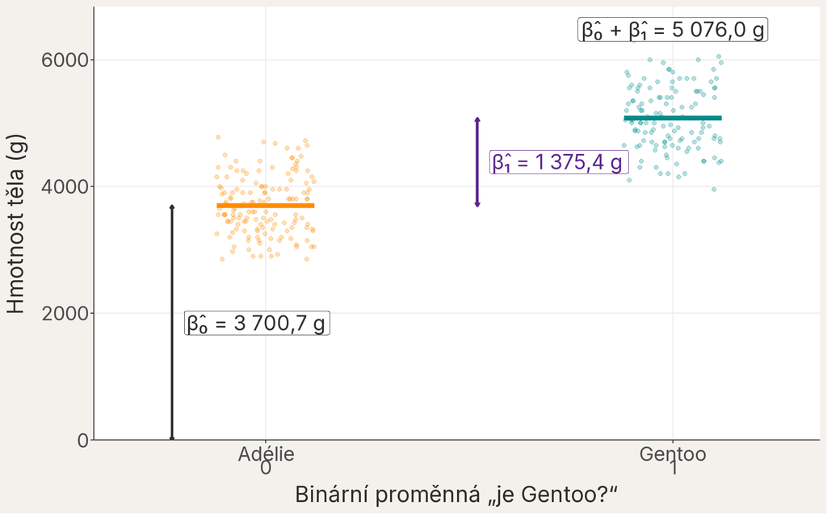

Dva koeficienty dvouskupinového modelu přímo v datech. Intercept β̂₀ je vzdálenost průměrové úsečky Adélie od nuly; koeficient β̂₁ je rozdíl Gentoo minus Adélie.

Intercept 3 700,7 g, tedy černá šipka, je průměr referenční skupiny Adélie. Koeficient `druhGentoo` 1 375,4 g, tedy fialová šipka, je rozdíl **Gentoo minus Adélie**. Když obě šipky složíme za sebe, dostaneme se na modrozelenou úsečku: jejich součet 5 076,0 g je průměr Gentoo, který je napsaný i v popisku nad body tohoto druhu.

**TipDoplňující: co se změní, když zvolíme jinou referenční skupinu?**

Referenci můžeme změnit funkcí `relevel()`. Když jako základ zvolíme Gentoo, intercept se stane průměrem Gentoo a rozdílový koeficient bude Adélie minus Gentoo. Odhadnuté skupinové průměryHodnota odezvy, kterou fitovaný model přiřadí pozorování na základě jeho hodnot prediktorů; značí se často ŷ., residuaRozdíl mezi pozorovanou hodnotou odezvy a hodnotou odhadnutou modelem: eᵢ = yᵢ − ŷᵢ. i biologický obsah modelu zůstanou stejné; změní se pouze způsob jejich zápisu.

```r
data_reference_gentoo <- data_dva_druhy
data_reference_gentoo$druh <-
  relevel(
    x = data_reference_gentoo$druh,
    ref = "Gentoo"
  )

levels(x = data_reference_gentoo$druh)
```

```
[1] "Gentoo" "Adelie"
```

```r
mod_reference_gentoo <-
  lm(
    formula = hmotnost_tela_g ~ druh,
    data = data_reference_gentoo
  )

coef(object = mod_reference_gentoo)
```

```
(Intercept)  druhAdelie
   5076.016   -1375.354
```

Při referenční skupině Gentoo je intercept 5 076,0 g a koeficient `druhAdelie` je -1 375,4 g. Součet opět vrátí průměr Adélie 3 700,7 g.

**PoznámkaVe studii s kontrolou nastavte referenční skupinu záměrně**

Pokud má studie skutečnou kontrolní skupinu, je obvykle nejčitelnější nastavit ji jako referenční skupinu. Intercept potom vyjadřuje průměr kontroly a každý léčebný koeficient odpovídá přímo otázce **ošetření minus kontrola**.

```r
data_studie$skupina <-
  relevel(
    x = data_studie$skupina,
    ref = "kontrola"
  )

levels(x = data_studie$skupina)
```

Tato volba pouze zpřehlední koeficienty. Nevytváří randomizaci, kontrolní podmínku ani kauzální důkaz — ty závisejí na designu studie. Změna referenční skupiny také nemění odhadnuté skupinové průměry, residua ani celkový test modelu.

**UpozorněníCo netestuje řádek interceptu**

P-hodnotaPravděpodobnost, že bychom při platnosti nulové hypotézy pozorovali data alespoň tak extrémní jako naše skutečná data. v řádku interceptu porovnává průměr Adélie s nulovou hmotností. Nulová hmotnost není naše biologická otázka. Otázku rozdílu druhů ve dvouskupinovém modelu najdeme v řádku `druhGentoo`.

## 9 Odhadnuté hodnoty a residua nezmizely

V modelu s numerickým prediktoremProměnná, pomocí níž vysvětlujeme variabilitu odezvy; v notaci y ~ x je prediktor x. měla každá délka ploutve vlastní hodnotu na přímce. V modelu se dvěma skupinami existují jen dvě odhadnuté hodnotyHodnota odezvy, kterou fitovaný model přiřadí pozorování na základě jeho hodnot prediktorů; značí se často ŷ.: průměrSoučet hodnot vydělený jejich počtem; nejběžnější míra polohy (střední hodnoty). Adélie a průměr Gentoo. Každý jedinec stejného druhu dostane stejnou odhadnutou hmotnost, ale vlastní residuumRozdíl mezi pozorovanou hodnotou odezvy a hodnotou odhadnutou modelem: eᵢ = yᵢ − ŷᵢ..

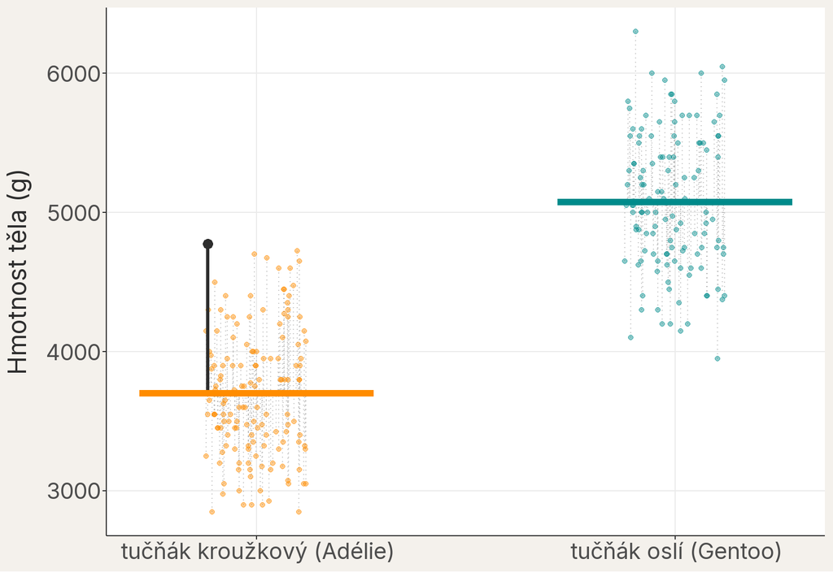

Každý jedinec sdílí odhadnutou hodnotu svého druhu. Body jsou kvůli překryvu mírně posunuty do stran. Tenké svislé úsečky spojují skutečné body s odhadem a jsou tedy residui; jedno residuum je zvýrazněno.

Pro zvýrazněného tučňáka kroužkového (jeho residuum je ze všech Adélie největší) platí slovy:

$$\text{residuum}
=
\text{naměřená hmotnost}
-
\text{odhadnutá hmotnost}.$$

Po dosazení čísel ze stejného řádku dat a z výšky průměrové úsečky:

$$\begin{aligned}
\text{residuum}
&=
\text{4 775,0}
-
\text{3 700,7} \\
&=
\text{1 074,3}\ \text{g}.
\end{aligned}$$

Obecný zápis používá stejné symboly jako u přímky:

$$e_i = y_i - \hat{y}_i.$$

```r
# Z modelu získáme odhadnutou hmotnost každého jedince
data_dva_druhy$odhadnuta_hmotnost_g <-
  fitted(object = mod_dva_druhy)

# Residuum je měření minus odhadnutá hodnota
data_dva_druhy$residuum_g <-
  resid(object = mod_dva_druhy)

# Zkontrolujeme první řádky obou nových sloupců
head(
  data_dva_druhy[
    , c(
      "druh",
      "hmotnost_tela_g",
      "odhadnuta_hmotnost_g",
      "residuum_g"
    )
  ]
)
```

```
    druh hmotnost_tela_g odhadnuta_hmotnost_g residuum_g
1 Adelie            3750             3700.662   49.33775
2 Adelie            3800             3700.662   99.33775
3 Adelie            3250             3700.662 -450.66225
5 Adelie            3450             3700.662 -250.66225
6 Adelie            3650             3700.662  -50.66225
7 Adelie            3625             3700.662  -75.66225
```

**DůležitéCo zůstalo stejné**

Lineární modelStatistický model, v němž je průměrná odezva součtem interceptu a prediktorů násobených koeficienty; lineární je v koeficientech, takže nemusí jít jen o přímku. stále rozděluje každou naměřenou hodnotu na systematickou část a residuum. U numerického prediktoru byla systematickou částí přímka; u kategoriálního prediktoruProměnná nabývající hodnot z omezeného počtu kategorií; může být nominální (bez pořadí) nebo ordinální (s pořadím). jsou jí skupinové průměry.

## 10 Jak velký a přesný je rozdíl dvou druhů?

Z dlouhého výstupu `summary()` vytáhneme jen dva odhadnuté koeficientyČíslo vypočtené z pozorovaných dat jako přiblížení neznámé vlastnosti nebo parametru; jiný srovnatelný výběr může dát jiný odhad.. Funkce `coef()` je užitečná právě ve chvíli, kdy víme, na které hodnoty se chceme zaměřit:

```r
coef(object = mod_dva_druhy)
```

```
(Intercept)  druhGentoo
   3700.662    1375.354
```

Koeficient `druhGentoo` odhaduje rozdíl 1 375,4 g. Podobně jako v předchozích dvou lekcích odhad doplníme standardní chybouMíra přesnosti odhadu parametru (průměru, sklonu…); odhaduje z jediného výběru, jak moc by se odhady typicky lišily mezi opakovanými výběry stejné velikosti. a 95% intervalem spolehlivostiRozsah hodnot vypočtený z dat postupem, který při opakovaných výběrech pokryje skutečnou hodnotu parametru ve zvoleném podílu případů (typicky 95 %)..

Interval nevzniká jako další nezávislé číslo. Připomeňme si z lekce o nejistotě, jak se vypočítá ze stejného odhadu a standardní chyby. Slovy:

$$95\%\ \text{interval}
=
\text{odhad rozdílu}
\pm
\text{kritická hodnota}
\cdot
\text{standardní chyba rozdílu}.$$

Po dosazení odhadu, kritické hodnoty (vysvětlené níže) a standardní chyby z řádku `druhGentoo`:

$$95\%\ \text{interval}
=
\text{1 375,4}
\pm
\text{1,969}
\cdot
\text{58,24}
=
\text{1 260,7}\ \text{až}\ \text{1 490,0}\ \text{g}.$$

Se symboly, kde $\hat{\beta}_1$ je odhadnutý rozdíl Gentoo minus Adélie a $\operatorname{SE}(\hat{\beta}_1)$ jeho standardní chyba:

$$95\%\ \text{interval}
=
\hat{\beta}_1
\pm
\underbrace{t_{0{,}975,\,df}}_{\text{kritická hodnota}}
\cdot
\operatorname{SE}(\hat{\beta}_1).$$

Pro 95% interval necháváme 2,5 % t-rozděleníSouměrné rozdělení podobné normálnímu, ale s těžšími chvosty; jeho tvar určují stupně volnosti a používá se pro t-statistiku a intervaly spolehlivosti. v každém krajním chvostu. Kritická hodnotaNásobitel standardní chyby použitý při konstrukci intervalu, nebo hranice testové statistiky v testu; závisí na hladině, stupních volnosti a zvoleném rozdělení. proto závisí na zvolené hladině 95 %Zvolená dlouhodobá úspěšnost postupu pro konstrukci intervalu spolehlivosti, například 95 %, při opakování za srovnatelných podmínek a splnění předpokladů. a na 272 residuálních stupních volnostiPočet nezávislých informací dostupných pro odhad parametru; počet pozorování minus počet odhadovaných parametrů.; zde je 1,969. V minulé lekci jsme kritickou hodnotu četli z tabulky; funkce `qt()` ji spočítá pro libovolný počet stupňů volnosti. Běžně tento výpočet dělat nemusíte: interval rovnou vrátí `confint()`.

```r
# Vezmeme odhad a standardní chybu z řádku druhGentoo
tabulka_koeficientu <- coef(object = summary(object = mod_dva_druhy))
odhad_rozdilu <- tabulka_koeficientu["druhGentoo", "Estimate"]
standardni_chyba <- tabulka_koeficientu["druhGentoo", "Std. Error"]

# Kritická hodnota pro 95% interval a residuální stupně volnosti
kriticka_hodnota <-
  qt(
    p = 0.975,
    df = df.residual(object = mod_dva_druhy)
  )

dolni_hranice <- odhad_rozdilu - kriticka_hodnota * standardni_chyba
horni_hranice <- odhad_rozdilu + kriticka_hodnota * standardni_chyba

c(dolni_hranice = dolni_hranice, horni_hranice = horni_hranice)
```

```
dolni_hranice horni_hranice
     1260.687      1490.021
```

```r
# Stejný výpočet pohodlně provede confint()
confint(object = mod_dva_druhy)["druhGentoo", ]
```

```
   2.5 %   97.5 %
1260.687 1490.021
```

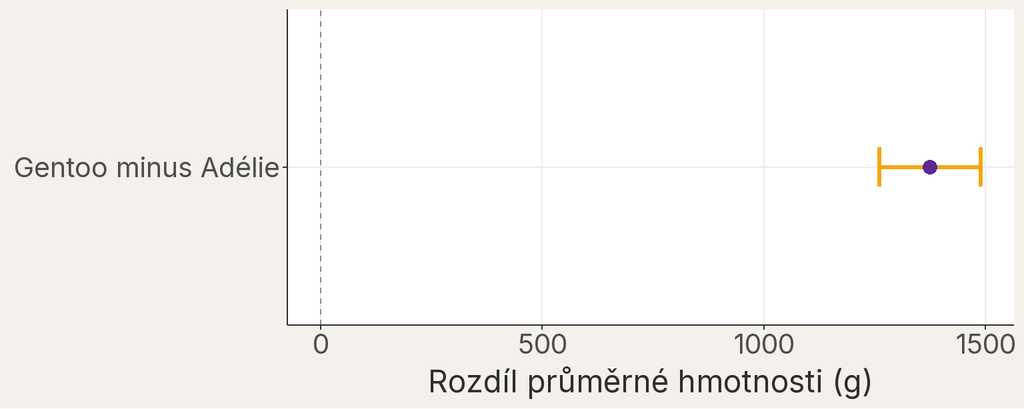

Odhad rozdílu průměrné hmotnosti Gentoo minus Adélie a jeho 95% interval spolehlivosti. Nula znamená stejné průměry.

Interval sahá od 1 260,7 do 1 490,0 g. Celý leží nad nulou, ale jeho hlavním sdělením není pouze „nula uvnitř / nula vně“. Ukazuje také, jak velký rozdíl je s daty a modelem slučitelný.

### 10.1 Je rozdíl slučitelný s nulou?

Nulová hypotézaVýchozí předpoklad, který testujeme - typicky ‘efekt je nulový’ nebo ‘skupiny se neliší’; p-hodnota udává pravděpodobnost dat alespoň tak extrémních jako naše za předpokladu platnosti H₀. a alternativaTvrzení, které připouští to, co nulová hypotéza vylučuje - typicky ‘efekt není nulový’ nebo ‘skupiny se liší’; značí se H_A. mluví o rozdílu průměrnýchSoučet hodnot vydělený jejich počtem; nejběžnější míra polohy (střední hodnoty). hmotností obou druhů v širší populaciCelá množina jednotek nebo širší proces, o kterém chceme pomocí výběru něco zjistit; její vlastnosti (parametry) obvykle neznáme., ze které změření tučňáci pocházejí:

$$H_0:
\text{průměr Gentoo}
-
\text{průměr Adélie}
= 0,$$

$$H_A:
\text{průměr Gentoo}
-
\text{průměr Adélie}
\neq 0.$$

Se symboly jde o tvrzení o populačním koeficientu: $H_0: \beta_1 = 0$ a $H_A: \beta_1 \neq 0$. Pro výpočet si znovu zobrazíme celý výstup modelu. V řádku `druhGentoo` stojí vedle sebe všechny tři hodnoty, které potřebujeme: odhad rozdílu, jeho standardní chyba a vypočtená t-statistikaTestová statistika: rozdíl odhadu od hodnoty v nulové hypotéze (obvykle 0) vydělený standardní chybou; říká, o kolik standardních chyb je odhad od nuly..

```r
summary(object = mod_dva_druhy)
```

```
Call:
lm(formula = hmotnost_tela_g ~ druh, data = data_dva_druhy)

Residuals:
     Min       1Q   Median       3Q      Max
-1126.02  -369.50   -26.02   343.00  1223.98

Coefficients:
            Estimate Std. Error t value Pr(>|t|)
(Intercept)  3700.66      39.02   94.83   <2e-16 ***
druhGentoo   1375.35      58.24   23.61   <2e-16 ***
---
Signif. codes:  0 '***' 0.001 '**' 0.01 '*' 0.05 '.' 0.1 ' ' 1

Residual standard error: 479.5 on 272 degrees of freedom
Multiple R-squared:  0.6721,    Adjusted R-squared:  0.6709
F-statistic: 557.6 on 1 and 272 DF,  p-value: < 2.2e-16
```

V řádku `druhGentoo` tedy čteme `Estimate` = 1 375,35, `Std. Error` = 58,24 a `t value` = 23,61. Následující rovnice pouze ukazuje, jak R ze dvou prvních sloupců získalo třetí.

Z předchozí lekce známe vztah mezi odhadem, nulovou hodnotou a jeho nejistotouRozsah, v němž nevíme přesnou hodnotu parametru kvůli omezenému výběru a výběrové variabilitě; kvantifikuje se pomocí standardních chyb a intervalů spolehlivosti.. Slovy:

$$\text{t-statistika}
=
\frac{
\text{odhadnutý rozdíl}-\text{nulový rozdíl}
}{
\text{standardní chyba rozdílu}
}.$$

Po dosazení čísel z řádku `druhGentoo`:

$$\begin{aligned}
t
&=
\frac{
\text{1 375,4}-0
}{
\text{58,2}
} \\
&=
\text{23,61}.
\end{aligned}$$

Obecně:

$$t = \frac{\hat{\beta}_1-0}{\operatorname{SE}(\hat{\beta}_1)}.$$

Stejně jako v předchozí lekci můžeme výsledek umístit do t-rozdělení očekávaného při nulové hypotéze. Musíme ale rozlišit dvě různá čísla:

- **kritické hranice** jsou zde $-\text{1,969}$ a $+\text{1,969}$. Oddělují prostředních 95 % nulového t-rozdělení od krajních 5 %: v každém chvostu zůstává 2,5 %. Stejnou kladnou kritickou hodnotu jsme použili už při výpočtu 95% intervalu spolehlivosti;
- **pozorovaná t-statistika** je $+\text{23,61}$. Tu jsme právě vypočítali z řádku `druhGentoo` v `summary()`.

Kritické hranice tedy **nejsou** výsledkem našeho testu. Vymezují předem zvolené rozhodovací oblasti pro $\alpha=0{,}05$. Náš výsledek $t=+\text{23,61}$ leží mnohem dále od nuly. Protože testujeme oboustrannou otázku, sledujeme také stejně vzdálenou zrcadlovou hranici $-\text{23,61}$. P-hodnotaPravděpodobnost, že bychom při platnosti nulové hypotézy pozorovali data alespoň tak extrémní jako naše skutečná data. je součet ploch nulového t-rozdělení za těmito dvěma hranicemi, nikoli plocha za kritickými hodnotami.

Následující graf proto používá dva panely: první zvětší kritické hranice a oblasti o celkové ploše $\alpha=0{,}05$; druhý ukáže skutečně pozorované $t$ a jeho zrcadlovou hranici na celé ose.

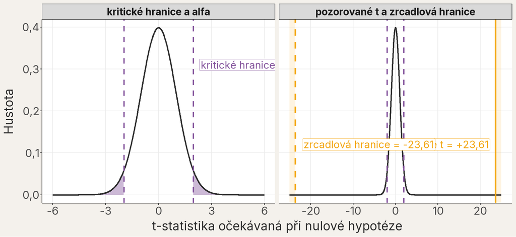

T-rozdělení při nulové hypotéze. Levý panel ukazuje kritické hranice a fialové chvosty o celkové ploše alfa = 0,05. V pravém panelu fialové čáry tyto hranice připomínají, zatímco oranžové pásy označují oblasti za pozorovaným t = 23,61 a zrcadlovou hranicí −23,61. P-hodnota je plocha pod t-křivkou uvnitř těchto oranžových oblastí.

Pozorovaný rozdíl leží 23,61 standardních chyb nad nulou, takže skutečně pozorovaná t-statistika je $+\text{23,61}$. Záporná hodnota $-\text{23,61}$ nebyla pozorována; je to zrcadlová hranice potřebná pro oboustrannou otázku. Při 272 residuálních stupních volnosti je součet ploch za oběma hranicemi, tedy p-hodnota, < 0,001. Za předpokladů modelu jsou data velmi obtížně slučitelná s přesně nulovým rozdílem mezi těmito dvěma druhy. Slovo „za předpokladů“ je důležité: residuaRozdíl mezi pozorovanou hodnotou odezvy a hodnotou odhadnutou modelem: eᵢ = yᵢ − ŷᵢ. tohoto modelu kontrolujeme stejně jako u přímky. Jak to vypadá u kategoriálního prediktoru, ukážeme níže na modelu se třemi druhy. Průměry Adélie a Gentoo jsou v obou modelech stejné, takže tito tučňáci mají i stejná residua a závěry z grafů platí také pro dva druhy.

### 10.2 Historická poznámka: dvouvýběrový t-test v literatuře

Statistické metody se historicky vyučovaly jako soubor samostatně pojmenovaných testů pro různé situace: jeden test pro dva průměry, jiný pro více průměrů, další pro vztah dvou numerických proměnných. Takové názvy byly praktické v době ručních výpočtů a tabulek, a proto zůstávají v učebnicích, článcích i nabídkách statistických programů dodnes.

Mnoho těchto klasických postupů ale můžeme zapsat jako speciální případy jednoho regresního modelu. Dvouvýběrový t-testTest založený na t-statistice (odhad dělený standardní chybou); nejčastěji porovnává průměry dvou skupin nebo testuje, zda je koeficient modelu nulový. se společným rozptylemSoučet čtverců odchylek od průměru dělený n − 1; míra variability dat. Odmocnina rozptylu je směrodatná odchylka. používá za stejných předpokladů tentýž odhad rozdílu, standardní chybu, t-statistiku a p-hodnotu jako koeficient `druhGentoo` v našem dvouskupinovém lineárním modeluStatistický model, v němž je průměrná odezva součtem interceptu a prediktorů násobených koeficienty; lineární je v koeficientech, takže nemusí jít jen o přímku.. Nemusíme se tedy učit nový způsob uvažování: biologickou otázku, odhad, nejistotu i test stále čteme z jednoho modelového rámce.

Název **dvouvýběrový t-test** však budeme potkávat v další literatuře. Následující příklad proto ukazuje, jak známý modelový výsledek přeložit do historického názvu testu a zpět. Nejde o další nesouvisející analýzu. Aby znaménko odpovídalo našemu koeficientu, odečteme Adélie od Gentoo.

**DůležitéProč tento historický název uvádíme**

Když v knize uvidíte dvouvýběrový t-test se společným rozptylem, můžete si jej představit jako lineární model `y ~ skupina` se dvěma úrovněmi. Při čtení výsledku se znovu ptejte na rozdíl průměrů, jeho standardní chybu, t-statistiku a p-hodnotu.

```r
# Připravíme hmotnosti obou skupin ve směru Gentoo minus Adélie
vec_gentoo <-
  data_dva_druhy$hmotnost_tela_g[
    data_dva_druhy$druh == "Gentoo"
  ]
vec_adelie <-
  data_dva_druhy$hmotnost_tela_g[
    data_dva_druhy$druh == "Adelie"
  ]

# Test se společným rozptylem odpovídá dvouskupinovému lm()
t.test(
  x = vec_gentoo,
  y = vec_adelie,
  var.equal = TRUE
)
```

```
    Two Sample t-test

data:  vec_gentoo and vec_adelie
t = 23.614, df = 272, p-value < 2.2e-16
alternative hypothesis: true difference in means is not equal to 0
95 percent confidence interval:
 1260.687 1490.021
sample estimates:
mean of x mean of y
 5076.016  3700.662
```

Stejná dvouskupinová otázka zapsaná jako koeficient lineárního modelu a jako t-test.

| Postup | Rozdíl Gentoo − Adélie (g) | t-statistika | df |
| --- | --- | --- | --- |
| koeficient v lm() | 1375,4 | 23,61 | 272 |
| t-test se společným rozptylem | 1375,4 | 23,61 | 272 |

**UpozorněníVýchozí t.test() v R je Welchův test**

Bez argumentu `var.equal = TRUE` používá R **Welchův t-testVarianta dvouvýběrového t-testu, která nepředpokládá shodné rozptyly obou skupin; je výchozí volbou funkce t.test() v R.**, který nevyžaduje společný rozptyl skupin a může mít jiné stupně volnosti i mírně jiný interval. Není proto pravda, že každý výstup `t.test()` musí být číselně totožný s obyčejným `lm()`. Totožnost v tabulce platí pro stejnou otázku a stejné předpoklady.

## 11 Tři druhy, stejná formule

Do dat se vrací tučňák uzdičkový (Chinstrap). Do `lm()` nemusíme přidávat nový druh ručně: faktor `druh` už obsahuje všechny tři úrovněJedna z kategorií kategoriální proměnné uložené v R jako faktor, například jeden druh z proměnné druh..

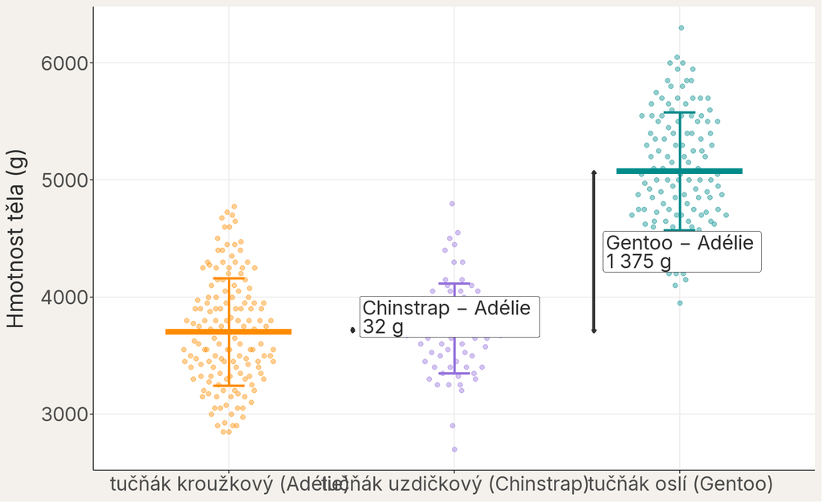

Tři druhy s průměrem ± 1 SD. Svislé závorky ukazují oba rozdíly, které model přímo vyjadřuje vůči referenčnímu druhu Adélie.

PrůměrySoučet hodnot vydělený jejich počtem; nejběžnější míra polohy (střední hodnoty). Adélie a Chinstrap leží blízko sebe, zatímco průměr Gentoo je mnohem výše. To je přesně situace, ve které potřebujeme odlišit tři otázky: jak se jednotlivé skupiny liší od referenční skupiny, zda jsou všechny tři průměry celkově stejné a které konkrétní dvojice chceme porovnat.

```r
# Fitujeme stejnou formuli na všech třech druzích
mod_tri_druhy <-
  lm(
    formula = hmotnost_tela_g ~ druh,
    data = data_tucnaci
  )

# Koeficienty stále čteme vzhledem k referenčnímu druhu Adélie
coef(object = mod_tri_druhy)
```

```
  (Intercept) druhChinstrap    druhGentoo
   3700.66225      32.42598    1375.35401
```

```r
confint(object = mod_tri_druhy)
```

```
                  2.5 %    97.5 %
(Intercept)   3626.6655 3774.6590
druhChinstrap -100.3686  165.2206
druhGentoo    1264.9117 1485.7963
```

### 11.1 Tři skupiny potřebují dva přepínače

Adélie zůstává referenční skupinouÚroveň kategoriálního prediktoru, vůči které model vyjadřuje rozdíly ostatních skupin; její průměr (při nulových numerických prediktorech) je intercept.. Model proto vytvoří přepínač pro Chinstrap a druhý pro Gentoo.

Kódování tří skupin při referenčním druhu Adélie. Přepínače nejsou biologické veličiny.

| Druh | je Chinstrap? | je Gentoo? | Odhadnutá hmotnost |
| --- | --- | --- | --- |
| tučňák kroužkový (Adélie) | 0 | 0 | β̂₀ |
| tučňák uzdičkový (Chinstrap) | 1 | 0 | β̂₀ + β̂₁ |
| tučňák oslí (Gentoo) | 0 | 1 | β̂₀ + β̂₂ |

Slovy:

$$\begin{aligned}
\text{odhadnutá hmotnost těla}
&=
\text{průměr Adélie} \\
&\quad +
\text{rozdíl Chinstrap vůči Adélie}
\cdot
\text{„je Chinstrap?“} \\
&\quad +
\text{rozdíl Gentoo vůči Adélie}
\cdot
\text{„je Gentoo?“}.
\end{aligned}$$

Po dosazení skutečných koeficientů a obou přepínačů z tabulky skončí každý řádek právě na průměru daného druhu:

$$\begin{aligned}
\widehat{\text{hmotnost}}_{\text{Adélie}}
&=
\text{3 700,7}
+
\text{32,4}\cdot 0
+
\text{1 375,4}\cdot 0
=
\text{3 700,7}\ \text{g}, \\
\widehat{\text{hmotnost}}_{\text{Chinstrap}}
&=
\text{3 700,7}
+
\text{32,4}\cdot 1
+
\text{1 375,4}\cdot 0
=
\text{3 733,1}\ \text{g}, \\
\widehat{\text{hmotnost}}_{\text{Gentoo}}
&=
\text{3 700,7}
+
\text{32,4}\cdot 0
+
\text{1 375,4}\cdot 1
=
\text{5 076,0}\ \text{g}.
\end{aligned}$$

Obecně: symbol $x_{\text{Chinstrap},i}$ je číselná odpověď na otázku „je pozorováníJeden zaznamenaný případ v datech, který obsahuje hodnoty jedné nebo více proměnných. $i$ Chinstrap?“ a $x_{\text{Gentoo},i}$ na otázku „je pozorování $i$ Gentoo?“. Oba nabývají hodnoty 0 nebo 1. Koeficient $\hat{\beta}_0$ (řádek `(Intercept)`) je odhadnutý průměr Adélie, $\hat{\beta}_1$ (řádek `druhChinstrap`) rozdíl Chinstrap minus Adélie a $\hat{\beta}_2$ (řádek `druhGentoo`) rozdíl Gentoo minus Adélie:

$$\hat{y}_i
=
\hat{\beta}_0
+
\hat{\beta}_1 x_{\text{Chinstrap},i}
+
\hat{\beta}_2 x_{\text{Gentoo},i}.$$

Koeficienty třískupinového modelu.

| Řádek výstupu | Odhad (g) | Význam při referenční skupině Adélie |
| --- | --- | --- |
| (Intercept) | 3700,7 | průměr Adélie |
| druhChinstrap | 32,4 | Chinstrap minus Adélie |
| druhGentoo | 1375,4 | Gentoo minus Adélie |

**UpozorněníKoeficienty neobsahují všechny dvojice**

Tabulka s referenční skupinou Adélie přímo odpovídá na otázky Chinstrap minus Adélie a Gentoo minus Adélie. Rozdíl Gentoo minus Chinstrap v ní není samostatný řádek, i když jej lze ze stejného modelu odvodit.

Průměr každého druhu zatím umíme složit z koeficientů ručně. Stejné hodnoty přímo vrátí funkce `emmeans()` z balíčku `emmeans`; pokud jej nemáte, nainstalujte jej jednou příkazem `install.packages("emmeans")` v Console. Název pochází z anglického *estimated marginal means*, česky **odhadnuté průměry**. Funkce pracuje s již fitovaným objektem `mod_tri_druhy`. **Nefitujeme nový model.** Argument `specs = ~ druh` říká, že chceme jeden průměr pro každý druh. V tomto jednoduchém modelu s jediným kategoriálním prediktoremProměnná nabývající hodnot z omezeného počtu kategorií; může být nominální (bez pořadí) nebo ordinální (s pořadím). jsou tyto hodnoty stejné jako skupinové průměry, které už známe z grafu.

```r
# Ze stejného modelu získáme odhadnutý průměr každého druhu
prumery_druhu <-
  emmeans::emmeans(
    object = mod_tri_druhy,
    specs = ~ druh
  )

prumery_druhu
```

```
 druh      emmean   SE  df lower.CL upper.CL
 Adelie      3701 37.6 339     3627     3775
 Chinstrap   3733 56.1 339     3623     3843
 Gentoo      5076 41.7 339     4994     5158

Confidence level used: 0.95
```

Výstup objektu `prumery_druhu` ukazuje všechny tři průměry odhadnuté modelem. Sloupec `emmean` obsahuje průměrnou hmotnost: 3 700,7 g pro Adélie, 3 733,1 g pro Chinstrap a 5 076,0 g pro Gentoo. Sloupec `SE` je standardní chybaMíra přesnosti odhadu parametru (průměru, sklonu…); odhaduje z jediného výběru, jak moc by se odhady typicky lišily mezi opakovanými výběry stejné velikosti. každého průměru, `df` udává residuální stupně volnostiPočet nezávislých informací dostupných pro odhad parametru; počet pozorování minus počet odhadovaných parametrů. a `lower.CL` s `upper.CL` vymezují 95% intervalRozsah hodnot vypočtený z dat postupem, který při opakovaných výběrech pokryje skutečnou hodnotu parametru ve zvoleném podílu případů (typicky 95 %). pro každý skupinový průměr zvlášť. Tyto intervaly popisují nejistotuRozsah, v němž nevíme přesnou hodnotu parametru kvůli omezenému výběru a výběrové variabilitě; kvantifikuje se pomocí standardních chyb a intervalů spolehlivosti. jednotlivých průměrů; nejsou to intervaly jejich vzájemných rozdílů. K rozdílům se vrátíme v části o post-hoc porovnáních.

## 12 Popisuje model data rozumně?

Než třískupinový model použijeme k testům, zkontrolujeme stejně jako u přímky diagnostiku modeluSoubor grafických a numerických kontrol ověřujících, zda jsou rozumně splněny předpoklady modelu: linearita, nezávislost pozorování, konstantní rozptyl a normalita residuí, a zda závěr nestojí na několika vlivných pozorováních.. U kategoriálního prediktoruProměnná nabývající hodnot z omezeného počtu kategorií; může být nominální (bez pořadí) nebo ordinální (s pořadím). má graf residuíRozdíl mezi pozorovanou hodnotou odezvy a hodnotou odhadnutou modelem: eᵢ = yᵢ − ŷᵢ. proti odhadnutým hodnotámHodnota odezvy, kterou fitovaný model přiřadí pozorování na základě jeho hodnot prediktorů; značí se často ŷ. zvláštní, ale očekávaný tvar: model odhaduje jen tři skupinové průměrySoučet hodnot vydělený jejich počtem; nejběžnější míra polohy (střední hodnoty)., takže body tvoří svislé pásy, jeden pro každý druh. Průměry Adélie a Chinstrap se liší jen o 32 g, proto jejich pásy na vodorovné ose téměř splývají a v grafu vidíme zdánlivě jen dva.

**UpozorněníCo od diagnostiky potřebujeme**

Test předpokládá nezávislá pozorováníJeden zaznamenaný případ v datech, který obsahuje hodnoty jedné nebo více proměnných., přibližně srovnatelnou variabilituObecný termín pro rozsah, v němž se hodnoty proměnné liší od sebe navzájem; kvantifikuje se pomocí rozptylu, SD, IQR nebo rozsahu. residuí ve skupinách a přibližně normální tvar residuí. Graf residuí proti odhadnutým hodnotám pomáhá posoudit srovnatelnost rozptyluSoučet čtverců odchylek od průměru dělený n − 1; míra variability dat. Odmocnina rozptylu je směrodatná odchylka.; Q–Q grafGraf, který porovnává seřazené hodnoty (typicky residua) s kvantily očekávanými u zvoleného rozdělení, nejčastěji normálního. pomáhá posoudit tvar rozděleníPopis toho, jaké hodnoty proměnná nabývá a jak často se vyskytují; může jít o pozorované rozdělení dat nebo o teoretické pravděpodobnostní rozdělení.. Nezávislost však z těchto grafů nepoznáme — musíme ji zdůvodnit způsobem, jakým byla pozorování získána. U tučňáků je každý řádek jeden jedinec, ale ptáci ze stejné kolonie nebo stejného roku si mohou být podobnější než ptáci z různých kolonií a let. Náš jednoduchý model s tím nepočítá, proto závěr omezíme na sledované kolonie.

**TipDoplňující: co když se skupiny liší variabilitou?**

Rozdílný rozptyl residuí ve skupinách (heteroskedasticitaJev, kdy rozptyl residuí není konstantní podél hodnot prediktoru - typicky se rozptýlení residuí zvětšuje s rostoucí odhadnutou hodnotou.) neznamená, že rozdíl průměrů zmizel. Znamená, že běžný model se společným residuálním rozptylem nemusí správně vyjádřit nejistotuRozsah, v němž nevíme přesnou hodnotu parametru kvůli omezenému výběru a výběrové variabilitě; kvantifikuje se pomocí standardních chyb a intervalů spolehlivosti. tohoto rozdílu. Nápovědou může být výrazně širší pás residuí u jednoho druhu nebo skupinové rozdělení s velmi odlišnou šířkou.

Pro dvě skupiny už jsme viděli Welchův t-testVarianta dvouvýběrového t-testu, která nepředpokládá shodné rozptyly obou skupin; je výchozí volbou funkce t.test() v R., který společný rozptyl nevyžaduje. Pro více skupin existuje Welchova ANOVA a v modelovém rámci také další způsoby výpočtu odolnější nejistoty. Volba řešení závisí na otázce, velikosti skupin a tvaru dat; diagnostický graf proto nemá sloužit jako automatický příkaz k transformaciMatematická operace použitá na hodnoty proměnné (např. logaritmus); mění tvar rozdělení i to, jaký vztah model popisuje, například násobný místo součtového. nebo mazání pozorování.

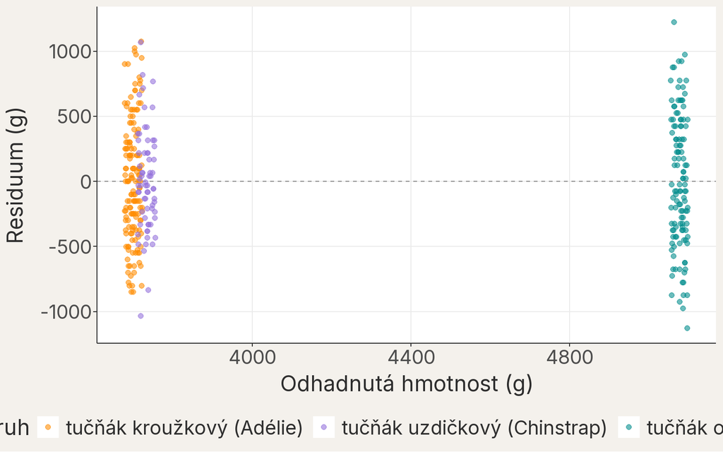

Residua proti odhadnutým hodnotám. Svislé pásy odpovídají skupinovým průměrům a jsou vlastností tohoto modelu, ne samy o sobě závadou. Pásy Adélie a Chinstrap téměř splývají, protože jejich průměry jsou skoro stejné.

Ve všech pásech jsou residua rozptýlena kolem nuly. Rozsah není dokonale totožný, ale žádná skupina nevytváří dramaticky odlišný vějíř.

Tvar rozdělení residuí ukáže histogramGraf zobrazující rozdělení hodnot numerické proměnné: hodnoty jsou rozděleny do sousedních intervalů (košů), výška sloupce udává četnost v daném koši., který znáte z lekce o lineárním modelu.

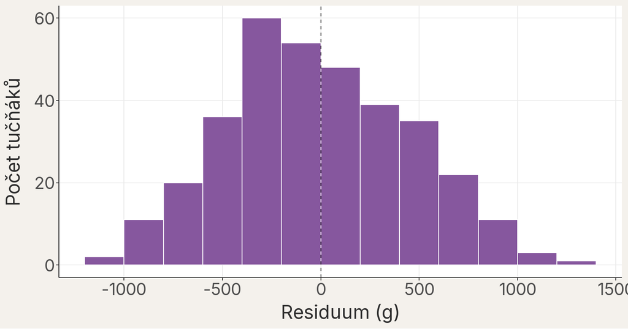

Histogram residuí modelu se třemi druhy. Kladná a záporná residua jsou zastoupena zhruba stejně a jeden vrchol leží blízko nuly.

Stejné grafy nakreslíte v základním R. Histogram residuí vznikne funkcí `hist()`, graf residuí proti odhadnutým hodnotám funkcí `plot()` a vodorovnou čáru v nule přidá `abline()`. Q–Q graf nakreslí `qqnorm()` a referenční přímku `qqline()`. Na rozdíl od grafů výše nebudou body obarvené podle druhu.

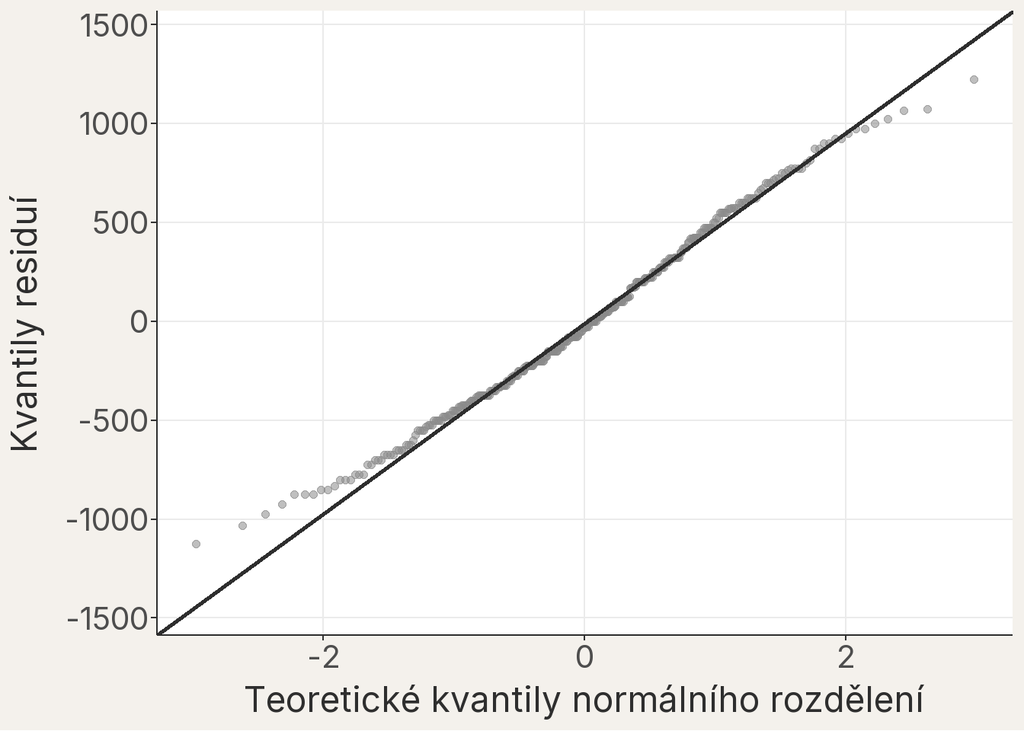

Q–Q graf residuí. Body převážně sledují referenční přímku; menší odchylky na koncích jsou u reálných dat běžné.

```r
# Histogram residuí
hist(
  x = resid(object = mod_tri_druhy),
  xlab = "Residuum (g)",
  main = ""
)

# Residua proti hodnotám odhadnutým modelem
plot(
  x = fitted(object = mod_tri_druhy),
  y = resid(object = mod_tri_druhy),
  xlab = "Odhadnutá hmotnost (g)",
  ylab = "Residuum (g)"
)

# Přerušovaná čára v nule
abline(h = 0, lty = 2)

# Q–Q graf residuí s referenční přímkou
qqnorm(y = resid(object = mod_tri_druhy))
qqline(y = resid(object = mod_tri_druhy))
```

Q–Q graf porovnává seřazená residua s hodnotami očekávanými při přibližně normálním tvaru. Body většinou sledují přímku a histogram má jeden vrchol blízko nuly. Model proto pro srovnání skupin nevykazuje problém, který by převzal hlavní biologický příběh. To neznamená, že jsou předpoklady „dokázané“; znamená to, že grafy neukazují zásadní rozpor.

### 12.1 Nestojí výsledek na několika tučňácích?

Stejně jako v minulých lekcích přidáme ještě Cookovu vzdálenostMíra vlivu jednoho pozorování na model: vyjadřuje, jak moc by se změnily odhadnuté hodnoty, kdybychom toto pozorování vynechali.. Pro každého tučňáka vyjadřuje, jak moc by se změnily odhady modelu, kdybychom právě tohoto tučňáka vynechali. U kategoriálního prediktoru mají všichni jedinci jednoho druhu stejný pákový efektMíra toho, jak neobvyklé hodnoty prediktorů má jedno pozorování ve srovnání s ostatními; nezávisí na naměřené odezvě., protože přispívají k odhadu téhož průměru. Největší hodnoty proto vidíme u tučňáků s velkým residuem a v menších skupinách.

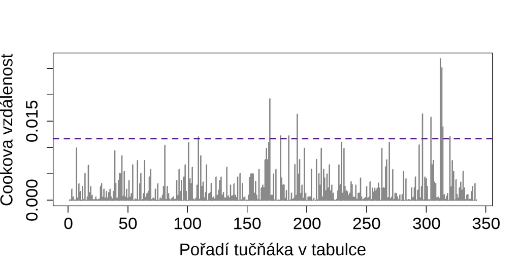

```r
# Cookova vzdálenost pro každého tučňáka
vec_cookova_vzdalenost <-
  cooks.distance(model = mod_tri_druhy)

plot(
  x = vec_cookova_vzdalenost,
  type = "h",
  lwd = 2,
  col = "#8A8A8A",
  xlab = "Pořadí tučňáka v tabulce",
  ylab = "Cookova vzdálenost"
)

abline(
  # Orientační hodnota 4/n, kde n je počet tučňáků
  h = 4 / nrow(x = data_tucnaci),
  lty = 2,
  lwd = 2,
  col = "#5D2890"
)
```

```r
# Kolik tučňáků leží nad orientační hodnotou?
sum(vec_cookova_vzdalenost > 4 / nrow(x = data_tucnaci))
```

```
[1] 11
```

Orientační hodnotu $4/n$ překračuje 11 z 342 tučňáků. To u velkého výběru nepřekvapí: hodnota $4/n$ s rostoucím počtem pozorování klesá, takže jen upozorňuje, kam se podívat, a není hranicí pro mazání. Největší Cookova vzdálenost je jen 0,027. Rozhodující je dopad na výsledek: vynechání jediného tučňáka změní kterýkoli koeficient nejvýše o 16 g a po vynechání všech 11 označených tučňáků zůstane rozdíl Gentoo minus Adélie 1 382 g místo 1 375 g. Výsledek tedy nestojí na několika jedincích. Označené tučňáky z dat neodstraňujeme: jsou to skutečná měření.

## 13 Jedna celková otázka: analýza rozptylu

U dvou skupin stačil jediný koeficient: Gentoo minus Adélie. U tří skupin už model obsahuje dva rozdílové koeficienty a jejich samostatné řádky neodpovídají přímo na jednu společnou otázku. Celková otázka zní, zda přidání proměnnéVlastnost zaznamenaná u pozorování, která může mezi pozorováními nabývat různých hodnot, například druh, délka nebo počet. `druh` zlepší popis dat jako celek:

$$H_0:
\text{všechny tři průměrné hmotnosti jsou stejné}.$$

AlternativaTvrzení, které připouští to, co nulová hypotéza vylučuje - typicky ‘efekt není nulový’ nebo ‘skupiny se liší’; značí se H_A. neříká, která dvojice se liší. Říká pouze, že alespoň jeden průměrSoučet hodnot vydělený jejich počtem; nejběžnější míra polohy (střední hodnoty). není stejný jako ostatní.

### 13.1 Jeden společný průměr proti třem skupinovým průměrům

Nulová hypotézaVýchozí předpoklad, který testujeme - typicky ‘efekt je nulový’ nebo ‘skupiny se neliší’; p-hodnota udává pravděpodobnost dat alespoň tak extrémních jako naše za předpokladu platnosti H₀. odpovídá jednoduššímu modelu bez prediktoruProměnná, pomocí níž vysvětlujeme variabilitu odezvy; v notaci y ~ x je prediktor x.: všem tučňákům přiřadí jeden společný průměr. Model s druhem je složitější a přiřadí každému jedinci průměr jeho druhu. Otázku analýzy rozptyluStatistický test porovnávající průměry tří a více skupin zároveň; testuje, zda se alespoň jedna skupina průměrem liší od ostatních. proto můžeme přeformulovat: **zkrátí tři skupinové průměry residuaRozdíl mezi pozorovanou hodnotou odezvy a hodnotou odhadnutou modelem: eᵢ = yᵢ − ŷᵢ. natolik, aby přidaná složitost modelu stála za to?**

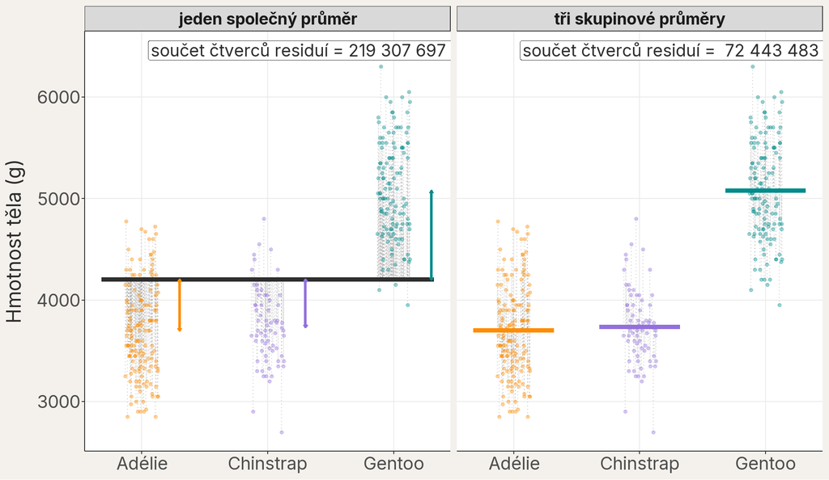

Stejná pozorování popsaná jedním společným průměrem a třemi skupinovými průměry. Body jsou kvůli překryvu mírně posunuty do stran. Tečkované svislice jsou všechna residua; šipky v levém panelu ukazují posun od společného průměru k průměrům druhů.

V levém panelu jsou residua vzdálenosti od jednoho společného průměru. V pravém panelu jsou vzdálenosti od průměru vlastního druhu. Součet čtverců residuíSoučet druhých mocnin všech residuí (RSS); vyjadřuje celkovou čtvercovou odchylku pozorovaných hodnot od hodnot odhadnutých modelem. klesne z 219 307 697 na 72 443 483 g². Rozdílné skupinové průměry tedy zachytí část variabilityObecný termín pro rozsah, v němž se hodnoty proměnné liší od sebe navzájem; kvantifikuje se pomocí rozptylu, SD, IQR nebo rozsahu., která v jednodušším modelu zůstávala v residuích.

Proč residua umocňujeme? Kdybychom pouze sečetli kladné a záporné vzdálenosti od průměru, navzájem by se vyrušily. Čtverce jsou vždy nezáporné a velkým odchylkám dávají větší váhu. Stejnou myšlenku součtu čtverců residuí už známe z fitování přímky.

Součet čtverců residuí modelu s jediným společným průměrem má vlastní název: je to **celkový součet čtvercůSoučet druhých mocnin odchylek pozorovaných hodnot odezvy od jejich průměru; popisuje celkovou variabilitu odezvy před použitím prediktorů.**, protože měří celkovou variabilitu hmotností kolem společného průměru. Pokles součtu čtverců můžeme zobrazit jako jeho rozdělení na dvě části. Slovy:

$$\text{celkový součet čtverců}
=
\text{součet čtverců mezi skupinami}
+
\text{součet čtverců uvnitř skupin (RSS)}.$$

Po dosazení hodnot z našich dvou modelů:

$$\text{219 307 697}
=
\text{146 864 214}
+
\text{72 443 483}.$$

Obecně:

$$SS_{\mathrm{total}} = SS_{\text{mezi}} + SS_{\text{uvnitř}},$$

kde $SS_{\mathrm{total}}$ je celkový součet čtverců, $SS_{\text{mezi}}$ **součet čtverců mezi skupinami**, tedy část, kterou zachytily rozdíly průměrů druhů, a $SS_{\text{uvnitř}}$ **součet čtverců uvnitř skupin**. Ten je totéž co součet čtverců residuí (RSS) modelu se třemi průměry.

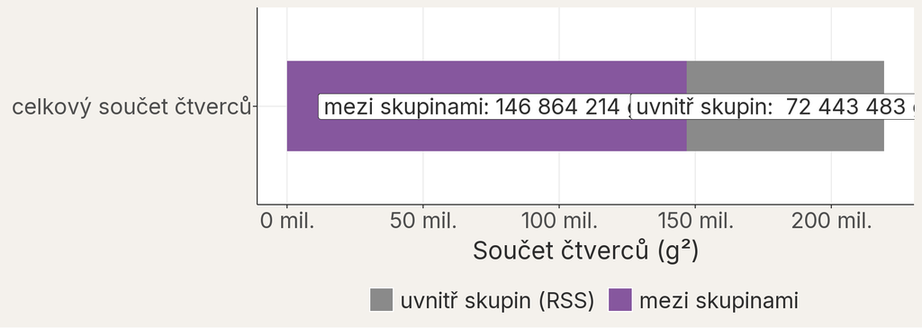

Celkový součet čtverců se po přidání druhu rozdělí na součet čtverců mezi skupinami, zachycený rozdíly skupinových průměrů, a součet čtverců uvnitř skupin (RSS), který stále zůstává uvnitř druhů.

### 13.2 Co porovnává F-statistika

Samotný pokles součtu čtverců nestačí. Složitější model téměř vždy residua alespoň trochu zkrátí, protože dostal více koeficientů. Potřebujeme proto porovnat dvě veličiny na férovém měřítku:

1. kolik variability zachytil každý přidaný rozdíl mezi skupinami;
2. jak velký čtverec residua typicky zůstává uvnitř skupin.

**F-statistikaTestová statistika porovnávající variabilitu zachycenou modelem s variabilitou, která zůstala v residuích; vyšší F = vyšší poměr signálu k šumu.** je poměr právě těchto dvou množství. Protože porovnává dvě variability, jmenuje se metoda analýza rozptylu, i když biologická otázka mluví o průměrech.

Slovy:

$$\text{F-statistika}
=
\frac{
\text{variabilita mezi skupinami na jeden přidaný rozdíl}
}{
\text{typický čtverec residua uvnitř skupin}
}.$$

Oba součty čtverců už máme. V grafu „jeden společný průměr proti třem skupinovým průměrům“ byl celkový součet čtverců 219 307 697 g² a součet čtverců uvnitř skupin (RSS tří průměrů) 72 443 483 g². Jejich rozdíl 146 864 214 g² je součet čtverců mezi skupinami, fialová část grafu rozkladu, kterou zachytil druh. Tato čísla ale nemůžeme porovnat přímo, protože nevznikla ze stejného množství informace. Než je vydělíme, musíme zjistit, z kolika nezávislých kousků informace každé z nich vzniklo.

### 13.3 Stupně volnosti: z kolika kousků informace součet vznikl?

Z lekce o testování hypotéz víme, že stupně volnostiPočet nezávislých informací dostupných pro odhad parametru; počet pozorování minus počet odhadovaných parametrů. říkají, kolik nezávislé informace zbývá poté, co jsme z dat něco odhadli. Každá odhadnutá hodnota spotřebuje jeden stupeň volnosti. V příkladu s pevným průměrem ho spotřebovalo jedno omezení a u přímky zbývalo $n-2$, protože jsme odhadli intercept a sklon. Stejnou úvahu teď použijeme na každou část rozkladu.

**Uvnitř skupin** počítáme odchylky každého tučňáka od průměru jeho druhu. Tento průměr jsme odhadli ze stejných dat, takže každý druh spotřebuje jeden stupeň volnosti na svůj průměr:

Stupně volnosti uvnitř jednotlivých druhů a jejich součet.

| Druh | Tučňáci | Odhadnuté průměry | Stupně volnosti |
| --- | --- | --- | --- |
| Adélie | 151 | 1 | 150 |
| Chinstrap | 68 | 1 | 67 |
| Gentoo | 123 | 1 | 122 |
| Uvnitř skupin celkem | 342 | 3 | 339 |

**Mezi skupinami** porovnáváme průměry tří druhů se společným průměrem. Model s jedním průměrem měl jeden koeficient a model se třemi průměry jich má 3: přidali jsme tedy 2 rozdílové koeficienty, `druhChinstrap` a `druhGentoo`. Stejný počet dostaneme i z odchylek průměrů druhů od společného průměru. Když známe společný průměr, počty tučňáků a průměry dvou druhů, průměr třetího druhu už dopočítáme, takže volně se mohou měnit jen 2 z těchto 3 odchylek.

**Celkový** součet čtverců počítá odchylky od jediného společného průměru, proto spotřebuje jediný stupeň volnosti. Slovy:

$$\begin{aligned}
\text{stupně volnosti uvnitř skupin}
&=
\text{počet pozorování} - \text{počet skupin}, \\
\text{stupně volnosti mezi skupinami}
&=
\text{počet skupin} - 1, \\
\text{celkové stupně volnosti}
&=
\text{počet pozorování} - 1.
\end{aligned}$$

Po dosazení hodnot:

$$\begin{aligned}
\text{uvnitř skupin:} \quad
150 + 67 + 122
&=
342 - 3
=
339, \\
\text{mezi skupinami:} \quad
3 - 1
&=
2, \\
\text{celkem:} \quad
342 - 1
&=
341.
\end{aligned}$$

Obecně:

$$df_{\text{uvnitř}} = n - k,
\qquad
df_{\text{mezi}} = k - 1,
\qquad
df_{\mathrm{total}} = n - 1,$$

kde $n$ je počet pozorováníJeden zaznamenaný případ v datech, který obsahuje hodnoty jedné nebo více proměnných. a $k$ počet skupin. Stupně volnosti se rozdělí stejně jako součty čtverců: $341 = 2 + 339$, tedy $df_{\mathrm{total}} = df_{\text{mezi}} + df_{\text{uvnitř}}$.

**QuestionKde se tato úvaha mýlí?**

Představte si tvrzení: „Druhy jsou 3, takže mezi skupinami máme 3 stupně volnosti. Uvnitř skupin jich zbývá $342 - 1$, protože odečítáme jeden průměr.“ Co byste opravili?

**DůležitéMožná odpověď**

Mezi skupinami jsou stupně volnosti jen 2, protože průměry druhů jsou navázané na společný průměr. Uvnitř skupin má každý druh svůj vlastní průměr, takže odečítáme 3 a zbývá 339. Hodnota 341 patří k celkovému součtu čtverců.

### 13.4 Průměrné čtverce: variabilita na jeden stupeň volnosti

Součet čtverců mezi skupinami 146 864 214 g² vznikl ze 2 stupňů volnosti, součet čtverců uvnitř skupin 72 443 483 g² z 339. Na férové měřítko je převedeme tak, že každý z nich vydělíme jeho stupni volnosti. Výsledkům se říká **průměrné čtverceSoučet čtverců vydělený příslušnými stupni volnosti; podíl dvou průměrných čtverců je F-statistika.**. Slovy:

$$\text{průměrný čtverec}
=
\frac{\text{součet čtverců}}{\text{stupně volnosti}}.$$

Po dosazení hodnot:

$$\begin{aligned}
\text{průměrný čtverec mezi skupinami}
&=
\frac{
\text{219 307 697}
-
\text{72 443 483}
}{
\text{2}
}
=
\frac{
\text{146 864 214}
}{
\text{2}
}
=
\text{73 432 107}, \\
\text{průměrný čtverec uvnitř skupin}
&=
\frac{
\text{72 443 483}
}{
\text{339}
}
=
\text{213 698}.
\end{aligned}$$

Obecně:

$$MS_{\text{mezi}} = \frac{SS_{\text{mezi}}}{df_{\text{mezi}}},
\qquad
MS_{\text{uvnitř}} = \frac{SS_{\text{uvnitř}}}{df_{\text{uvnitř}}}.$$

Symbol $MS$ označuje průměrný čtverec (*mean square*), $SS$ součet čtverců a $df$ příslušné stupně volnosti.

### 13.5 F-statistika je poměr průměrných čtverců

Kdyby druh nepomáhal, zlepšení připadající na jeden nový koeficient by bylo podobně velké jako běžný čtverec residua a $F$ by bylo kolem 1. Čím je čitatel větší vůči jmenovateli, tím více skupinové rozdíly vyčnívají nad variabilitu jedinců uvnitř skupin. Slovy:

$$\text{F-statistika}
=
\frac{\text{průměrný čtverec mezi skupinami}}{\text{průměrný čtverec uvnitř skupin}}.$$

Po dosazení hodnot:

$$F
=
\frac{
\text{73 432 107}
}{
\text{213 698}
}
=
\text{343,63}.$$

Obecně:

$$F
=
\frac{MS_{\text{mezi}}}{MS_{\text{uvnitř}}}.$$

F-statistika tak spojuje všechny předchozí kroky: rozdíly průměrů mění odhadnuté hodnotyHodnota odezvy, kterou fitovaný model přiřadí pozorování na základě jeho hodnot prediktorů; značí se často ŷ., tím zkracují residua, z residuí počítáme součty čtverců a jejich férově přepočtený poměr testuje společnou nulovou hypotézu.

```r
# Položíme celkovou otázku stejnému třískupinovému modelu
anova(object = mod_tri_druhy)
```

```
Analysis of Variance Table

Response: hmotnost_tela_g
           Df    Sum Sq  Mean Sq F value    Pr(>F)
druh        2 146864214 73432107  343.63 < 2.2e-16 ***
Residuals 339  72443483   213698
---
Signif. codes:  0 '***' 0.001 '**' 0.01 '*' 0.05 '.' 0.1 ' ' 1
```

### 13.6 Jak číst tabulku `anova()` řádek po řádku

Tabulka je kompaktní, ale každý údaj odpovídá kroku, který jsme už viděli v rovnici nebo grafu:

1. **Řádek `druh`** popisuje část variability zachycenou přidáním tří skupinových průměrů místo jednoho společného průměru. **Řádek `Residuals`** popisuje variabilitu, která zůstává kolem skupinových průměrů.
2. **`Df` pro `druh` je 2, `Df` pro `Residuals` je 339.** Jsou to stupně volnosti mezi skupinami a uvnitř skupin z naší tabulky. Celkových 341 stupňů volnosti tabulka neuvádí, ale je to jejich součet.
3. **`Sum Sq` pro `druh` je 146 864 214 g².** Je to součet čtverců mezi skupinami, tedy rozdíl celkového součtu čtverců a RSS tří průměrů, a fialová část předchozího rozkladového grafu. **`Sum Sq` pro `Residuals` je 72 443 483 g²**, tedy součet čtverců uvnitř skupin (RSS) – šedá část, která zůstává uvnitř druhů.
4. **`Mean Sq`** vznikne vydělením každého `Sum Sq` jeho `Df`: 73 432 107 g² mezi skupinami a 213 698 g² uvnitř skupin.
5. **`F value` je 343,63.** Je to poměr těchto dvou průměrných čtverců a stejnou hodnotu by vypsal i řádek `F-statistic` ve výstupu `summary()` tohoto modelu. Hodnota mnohem větší než 1 znamená, že rozdíly skupinových průměrů jsou velké vůči běžné variabilitě jedinců kolem těchto průměrů.
6. **`Pr(>F)` je p-hodnotaPravděpodobnost, že bychom při platnosti nulové hypotézy pozorovali data alespoň tak extrémní jako naše skutečná data..** Nejde o další nezávislý výpočet z dat; vzniká umístěním pozorovaného $F$ do nulového **F-rozděleníPopis toho, jaké hodnoty proměnná nabývá a jak často se vyskytují; může jít o pozorované rozdělení dat nebo o teoretické pravděpodobnostní rozdělení.** s 2 stupni volnosti pro čitatele a 339 pro jmenovatele.

### 13.7 Jak se z F-statistiky stane p-hodnota

Pokud by všechny tři populačníCelá množina jednotek nebo širší proces, o kterém chceme pomocí výběru něco zjistit; její vlastnosti (parametry) obvykle neznáme. průměry byly stejné a platily předpoklady modelu, opakované výběrySoubor pozorování, z něhož počítáme statistiky a pomocí něhož se snažíme popsat širší populaci nebo proces. by vytvářely hodnoty z F-rozdělení $F(2, 339)$. Zápis $F(2, 339)$ říká, které F-rozdělení máme na mysli. Podobně jako t-rozdělení i F-rozdělení mění tvar podle stupňů volnosti, jen k tomu potřebuje dvě čísla, protože F je poměr dvou průměrných čtverců. První číslo 2 jsou stupně volnosti čitatele, tedy mezi skupinami. Druhé číslo 339 jsou stupně volnosti jmenovatele, tedy uvnitř skupin. Při jiném počtu skupin nebo tučňáků bychom srovnávali s jinou křivkou.

P-hodnota je plocha napravo od naší pozorované hodnoty 343,63:

$$p
=
P\!\left(
F_{2,339}
\ge
\text{343,63}
\mid H_0
\right).$$

```r
# F a stupně volnosti vezmeme z tabulky anova()
tabulka_anova <- anova(object = mod_tri_druhy)
f_druh <- tabulka_anova["druh", "F value"]
df_druh <- tabulka_anova["druh", "Df"]
df_residua <- tabulka_anova["Residuals", "Df"]

# Plocha F-rozdělení napravo od pozorovaného F
pf(
  q = f_druh,
  df1 = df_druh,
  df2 = df_residua,
  lower.tail = FALSE
)
```

```
[1] 2.892368e-82
```

Argument `lower.tail = FALSE` říká R, že chceme pravý chvost: pravděpodobnost hodnot stejně velkých nebo větších než pozorované $F$. U našeho modelu je tato plocha tak malá, že ji v grafu prakticky neuvidíme.

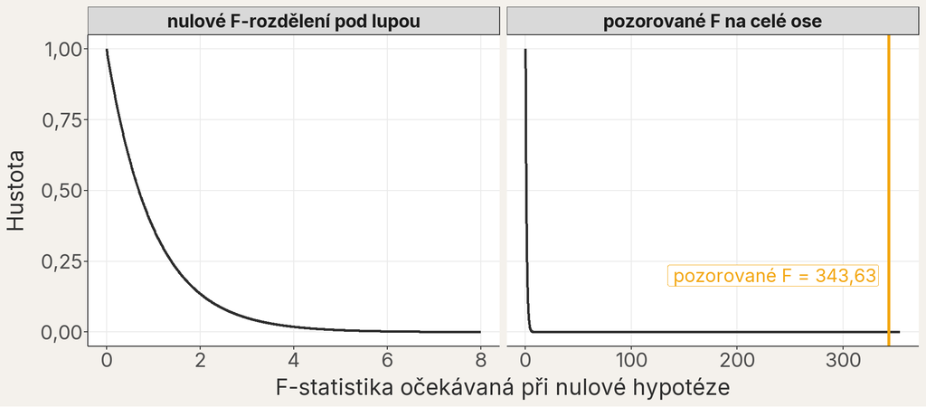

F-rozdělení očekávané při nulové hypotéze. Levý panel ukazuje běžné hodnoty blízko jedné; pravý panel umisťuje pozorovanou F-statistiku na skutečnou osu. P-hodnota je plocha napravo od oranžové čáry a je zde příliš malá, aby byla viditelná.

**TipDoplňující: různá F-rozdělení a různé p-hodnoty**

P-hodnota závisí na dvou věcech: na velikosti F a na tom, se kterým F-rozdělením ji srovnáváme. Graf ukazuje tři F-rozdělení a u každého tři hodnoty F. **Hodnoty 1, 3, 6 jsme zvolili jen pro ilustraci a nejsou to výsledky našeho modelu.** Pouze prostřední sloupec má stejné stupně volnosti jako model tučňáků; malá studie a studie se 6 skupinami jsou vymyšlené.

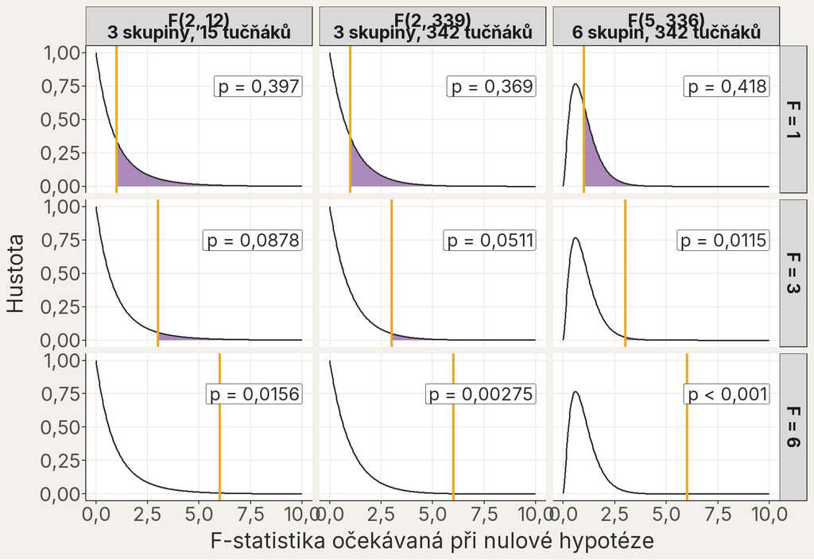

Tři F-rozdělení a tři ilustrační hodnoty F. Oranžová čára je zvolená hodnota F a fialová plocha napravo od ní je p-hodnota; u velkých F je tak malá, že ji téměř nevidíme. Hodnoty F nejsou výsledky modelu tučňáků.

V každém sloupci platí totéž: čím větší F, tím menší plocha napravo od něj, a tedy menší p-hodnota. Stejné F ale v různých sloupcích nedává stejnou p-hodnotu. Například F = 3 dává p = 0,0878 u malé studie, p = 0,0511 při stupních volnosti našeho modelu a p = 0,0115 při 6 skupinách.

Při malém počtu pozorování má křivka těžší pravý chvost, podobně jako t-křivky s malým počtem stupňů volnosti, takže velké hodnoty F nejsou tak neobvyklé. Proto vedle hodnoty F vždy uvádíme oba stupně volnosti. Naše pozorované F = 343,63 by v tomto grafu leželo daleko za pravým okrajem osy.

Pro tučňáky tedy vychází $F(2, 339)=\text{343,63}$ a p-hodnota je < 0,001.

**DůležitéVýsledek celkového testu**

Za předpokladů modelu jsou data velmi obtížně slučitelná s hypotézou, že všechny tři druhy mají stejnou průměrnou hmotnost.

**UpozorněníCelkový výsledek neříká, že se liší každá dvojice**

Malá p-hodnota analýzy rozptylu podporuje tvrzení, že alespoň jeden průměr se liší. Neurčuje však, které dvojice se liší, ani zda jsou všechny rozdíly biologicky důležité.

## 14 Post-hoc: které dvojice se liší?

F-test odpověděl na celkovou otázku: data jsou obtížně slučitelná s hypotézou tří stejných průměrůSoučet hodnot vydělený jejich počtem; nejběžnější míra polohy (střední hodnoty).. Neříká ale, které druhy se liší. Na to se ptají navazující otázky o konkrétních dvojicích. U tří druhů existují tři páry: Chinstrap minus Adélie, Gentoo minus Adélie a Gentoo minus Chinstrap.

Kdybychom každý pár testovali jako izolovanou novou studii, s rostoucím počtem testů by rostla šance na alespoň jeden náhodně extrémní výsledek. **Tukeyho post-hoc metodaPárová porovnání skupin, která společně vyhodnotí celou rodinu otázek typu ‘liší se skupina A od B?’ a upraví p-hodnoty i intervaly pro mnohonásobné porovnávání.** proto vyhodnotí celou rodinu párových otázek společně. Získáme **simultánní intervalyInterval z rodiny intervalů upravených tak, aby zvolené pokrytí (např. 95 %) platilo pro všechna porovnání najednou; je širší než samostatný interval.** a p-hodnotyPravděpodobnost, že bychom při platnosti nulové hypotézy pozorovali data alespoň tak extrémní jako naše skutečná data. upravené pro všechna tři porovnání. Co simultánní interval znamená, si vysvětlíme za chvíli.

**PoznámkaDvě různé otázky položené stejnému modelu**

- **Celkový F-test** se ptá, zda jsou **všechny skupinové průměry stejné**. Odpovídá jedním číslem pro všechny skupiny.
- **Post-hoc porovnání** se ptají, **které konkrétní dvojice** se liší a o kolik gramů. Tukeyho úprava sama zohlední, že se díváme na více dvojic současně, a nepotřebuje proto předchozí statisticky významnýOznačení výsledku, jehož p-hodnota je nejvýše zvolená hladina významnosti α; neříká nic o tom, zda je efekt velký nebo biologicky důležitý. F-test jako vstupenku.

Párová porovnání dávají smysl, když máme **tři a více skupin** a biologická otázka se týká konkrétních dvojic. U dvou skupin je jediná dvojice a odpověď už dává koeficient modelu. Když jsou párové rozdíly malé a jejich intervaly obsahují nulu, poctivý závěr zní, že data rozdíly neodlišují od nuly. Problémem by bylo vybrat si dodatečně jednu „zajímavou“ dvojici a uvést její neupravenou p-hodnotu, jako by šlo o jedinou předem položenou otázku.

### 14.1 Simultánní intervaly: 95 % pro celou sadu najednou

Obyčejný 95% interval spolehlivostiRozsah hodnot vypočtený z dat postupem, který při opakovaných výběrech pokryje skutečnou hodnotu parametru ve zvoleném podílu případů (typicky 95 %). je nastavený pro **jednu** předem vybranou veličinu: při opakování studie by přibližně 95 % takových intervalů pokrylo její skutečnou hodnotu. Zde ale čteme tři rozdíly současně. Kdyby měl každý obyčejný interval pětiprocentní riziko, že svou skutečnou hodnotu mine, šance, že ji alespoň jeden z celé sady mine, by byla větší než pět procent.

Simultánní intervaly (anglicky *simultaneous intervals*) jsou proto nastavené pro celou sadu najednou. Přibližně 95 % opakovaných **celých sad tří intervalů** by pokrylo všechny tři skutečné rozdíly současně. Tuto společnou ochranu platíme šířkou: Tukeyho metoda každý interval trochu rozšíří a p-hodnoty jsou větší než při izolovaném čtení jediné dvojice. Odhad rozdílu se přitom nemění, jak ukazuje tabulka.

Stejné tři rozdíly s obyčejnými a se simultánními intervaly. Pro závěr o všech třech dvojicích čteme simultánní intervaly.

| Porovnání | Rozdíl (g) | Obyčejný 95% interval (g) | Simultánní 95% interval (g) |
| --- | --- | --- | --- |
| Chinstrap minus Adélie | 32,4 | -100,4 až 165,2 | -126,5 až 191,4 |
| Gentoo minus Adélie | 1375,4 | 1 264,9 až 1 485,8 | 1 243,2 až 1 507,5 |
| Gentoo minus Chinstrap | 1342,9 | 1 205,5 až 1 480,3 | 1 178,5 až 1 507,4 |

Simultánní interval čteme stejně jako každý jiný interval spolehlivosti: ukazuje hodnoty rozdílu slučitelné s daty, a pokud obsahuje nulu, data rozdíl od nuly neodlišují. Liší se jen tím, že jeho 95 % platí pro celou sadu porovnání.

### 14.2 Párové rozdíly v R

Párové rozdíly lze v R spočítat mnoha způsoby, jako většinu věcí v R. My použijeme balíček `emmeans`, i když na první pohled vypadá složitěji než některé jiné cesty. Důvod je praktický: je velmi pružný a stejný postup nám poslouží i u složitějších modelů v dalších lekcích.

Vyjdeme z odhadnutých průměrů z části o třech druzích; pro připomenutí objekt `prumery_druhu` v kódu vytvoříme znovu stejným příkazem. Funkce `emmeans::contrast()` je pak porovná mezi sebou; rozdílu dvou průměrů se říká **kontrast**. **Ani tady nefitujeme nový model:** vše pochází z téhož lineárního modeluStatistický model, v němž je průměrná odezva součtem interceptu a prediktorů násobených koeficienty; lineární je v koeficientech, takže nemusí jít jen o přímku.. Metoda `revpairwise` zachová směr, který jsme používali v grafech: Chinstrap minus Adélie, Gentoo minus Adélie a Gentoo minus Chinstrap. Argument `adjust = "tukey"` říká, že intervaly a p-hodnoty mají zohlednit celou rodinu tří porovnání.

```r
# Připomeneme si odhadnuté průměry ze stejného modelu
prumery_druhu <-
  emmeans::emmeans(
    object = mod_tri_druhy,
    specs = ~ druh
  )

# Ze stejných odhadnutých průměrů vytvoříme tři párové rozdíly
post_hoc_druhy <-
  emmeans::contrast(
    object = prumery_druhu,
    method = "revpairwise",
    adjust = "tukey"
  )

summary(
  object = post_hoc_druhy,
  # První TRUE zobrazí intervaly, druhé t-testy a p-hodnoty
  infer = c(TRUE, TRUE)
)
```

```
 contrast           estimate   SE  df lower.CL upper.CL t.ratio p.value
 Chinstrap - Adelie     32.4 67.5 339     -127      191   0.480  0.8807
 Gentoo - Adelie      1375.4 56.1 339     1243     1508  24.495 <0.0001
 Gentoo - Chinstrap   1342.9 69.9 339     1178     1507  19.224 <0.0001

Confidence level used: 0.95
Conf-level adjustment: tukey method for comparing a family of 3 estimates
P value adjustment: tukey method for comparing a family of 3 estimates
```

Ve výstupu sledujeme řádky jednotlivých dvojic. Sloupec `estimate` je odhadnutý rozdíl průměrů, `lower.CL` a `upper.CL` jsou dolní a horní hranice simultánního intervalu a `p.value` je p-hodnota upravená pro společnou rodinu porovnání. Poznámky pod výstupem potvrzují, že Tukeyho úprava byla použita pro intervaly i p-hodnoty. Přehledněji si stejné hodnoty uspořádáme do tabulky.

Tukeyho post-hoc rozdíly, simultánní intervaly a p-hodnoty upravené pro tři porovnání.

| Porovnání | Rozdíl (g) | Dolní hranice (g) | Horní hranice (g) | Upravená p-hodnota |
| --- | --- | --- | --- | --- |
| Chinstrap minus Adélie | 32,4 | -126,5 | 191,4 | 0,881 |
| Gentoo minus Adélie | 1375,4 | 1243,2 | 1507,5 | < 0,001 |
| Gentoo minus Chinstrap | 1342,9 | 1178,5 | 1507,4 | < 0,001 |

Tabulka zachovává hlavní čísla z výstupu `summary(post_hoc_druhy)`. Graf je ukazuje na jedné ose: bod ukáže odhad rozdílu, vodorovná úsečka jeho simultánní interval a svislá čára nulu.

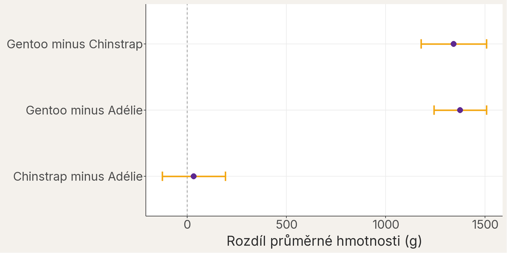

Tři Tukeyho post-hoc rozdíly a simultánní 95% intervaly. Nula znamená stejné průměry dané dvojice.

Rozdíl Chinstrap minus Adélie je 32,4 g a simultánní interval od -126,5 do 191,4 g protíná nulu. Data tedy tento malý rozdíl neodlišují od nuly. Oba rozdíly zahrnující Gentoo jsou přibližně 1 343 až 1 375 g a jejich intervaly leží celé nad nulou.

**DůležitéCelková a párová otázka dávají různé informace**

Analýza rozptyluStatistický test porovnávající průměry tří a více skupin zároveň; testuje, zda se alespoň jedna skupina průměrem liší od ostatních. ukázala, že všechny tři průměry nejsou stejné. Párová porovnání upřesnila proč: Gentoo se zřetelně liší od obou dalších druhů, zatímco Adélie a Chinstrap mají v tomto výběruSoubor pozorování, z něhož počítáme statistiky a pomocí něhož se snažíme popsat širší populaci nebo proces. velmi podobné průměrné hmotnosti.

**TipDoplňující: plánované kontrasty a post-hoc porovnání nejsou stejná otázka**

V této lekci klademe celkovou otázku a k ní systematicky prohlížíme všechny tři dvojice. To je post-hoc postup. Výzkumník však někdy ještě před sběrem dat určí jeden biologicky motivovaný kontrast, například „potápěčský druh proti průměru dvou pobřežních druhů“. Taková otázka není dodatečným hledáním nejzajímavější dvojice.

Předem plánovaný kontrast může být věcně přesnější než všechna párová srovnání a stejně jako Tukeyho porovnání nemusí čekat na výsledek celkového F-testu. Stále však musíme transparentně uvést všechny plánované otázky a při více kontrastech zvážit jejich společnou chybovost. Výpočet takových složitějších kontrastů patří do pokročilejší práce s modely.

## 15 Co jednoduchý model neoddělil

Rozdíly mezi druhy jsou v těchto datech **asociace**. Jedinci nebyli náhodně přiřazeni ke druhům a druhy nebyly na ostrovech zastoupeny stejně.

Počet jedinců jednotlivých druhů na třech ostrovech.

| Druh | Biscoe | Dream | Torgersen |
| --- | --- | --- | --- |
| tučňák kroužkový (Adélie) | 44 | 56 | 51 |
| tučňák uzdičkový (Chinstrap) | 0 | 68 | 0 |
| tučňák oslí (Gentoo) | 123 | 0 | 0 |

Všichni tučňáci uzdičkoví v tomto výběruSoubor pozorování, z něhož počítáme statistiky a pomocí něhož se snažíme popsat širší populaci nebo proces. pocházejí z ostrova Dream a všichni tučňáci oslí z ostrova Biscoe. Adélie byli měřeni na všech třech ostrovech. Jednoduchý model proto neumí oddělit druh od prostředí ostrova.

Pohlaví také souvisí s hmotností. Následující graf tuto strukturu pouze zviditelňuje; stále nefitujeme model s více prediktoryProměnná, pomocí níž vysvětlujeme variabilitu odezvy; v notaci y ~ x je prediktor x..

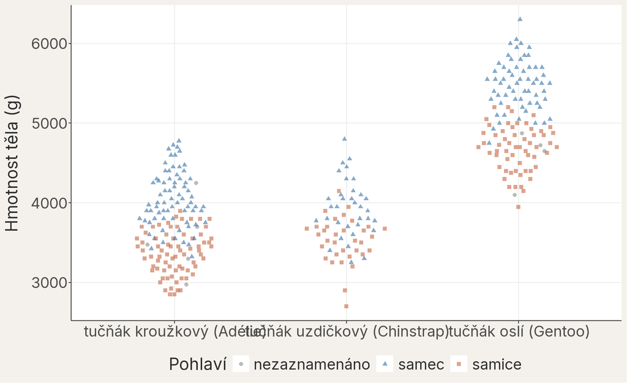

Hmotnosti tří druhů rozlišené podle zaznamenaného pohlaví. Šedé body mají pohlaví nezaznamenané.

## 16 Co tedy můžeme říct o tučňácích?

Správný závěr nezačíná p-hodnotouPravděpodobnost, že bychom při platnosti nulové hypotézy pozorovali data alespoň tak extrémní jako naše skutečná data.. Jeho jádrem je velikost rozdílů v gramech a jejich nejistotaRozsah, v němž nevíme přesnou hodnotu parametru kvůli omezenému výběru a výběrové variabilitě; kvantifikuje se pomocí standardních chyb a intervalů spolehlivosti.; testová informace a omezení studie je doplňují.

**QuestionSestavte závěr z pěti částí**

Napište krátký odstavec v pořadí: biologická otázka → rozdíly v gramech → intervalyRozsah hodnot vypočtený z dat postupem, který při opakovaných výběrech pokryje skutečnou hodnotu parametru ve zvoleném podílu případů (typicky 95 %). → celkový a párový test → omezení zobecnění a kauzality.

**DůležitéPříklad opatrného závěru**

Ptali jsme se, zda se liší průměrná hmotnost tří druhů tučňáků. V souboru 342 dospělých tučňáků z Palmerova souostroví byli tučňáci oslí (Gentoo) v průměru přibližně o 1 375 g těžší než tučňáci kroužkoví (Adélie) a o 1 343 g těžší než tučňáci uzdičkoví (Chinstrap); simultánní 95% intervalyInterval z rodiny intervalů upravených tak, aby zvolené pokrytí (např. 95 %) platilo pro všechna porovnání najednou; je širší než samostatný interval. obou rozdílů ležely celé nad nulou (od 1 243 do 1 508 g a od 1 178 do 1 507 g). PrůměrySoučet hodnot vydělený jejich počtem; nejběžnější míra polohy (střední hodnoty). Adélie a Chinstrap se lišily jen o 32 g a jejich interval od -127 do 191 g zahrnoval nulu, takže data tento malý rozdíl neodlišují od nuly. Celková analýza rozptyluStatistický test porovnávající průměry tří a více skupin zároveň; testuje, zda se alespoň jedna skupina průměrem liší od ostatních. byla s hypotézou tří stejných průměrů obtížně slučitelná ($F(2, 339) = \text{343,63}$; p-hodnota < 0,001). Jde o observační data: druh je v souboru propojený s ostrovem a hmotnost souvisí také s pohlavím, proto rozdíly nelze vykládat jako přímý účinek druhu a závěr platí pro sledované kolonie.

## 17 Co bude následovat dál

Model s jediným kategoriálním prediktorem odpovídá na jednu otázku: jak se liší průměrySoučet hodnot vydělený jejich počtem; nejběžnější míra polohy (střední hodnoty). druhů. Neumí ale oddělit druh od ostrova nebo pohlaví. Změnil by se odhadČíslo vypočtené z pozorovaných dat jako přiblížení neznámé vlastnosti nebo parametru; jiný srovnatelný výběr může dát jiný odhad. rozdílu mezi druhy, kdybychom porovnávali jedince stejného pohlaví nebo současně zohlednili ostrov? Na to potřebujeme model s více prediktoryProměnná, pomocí níž vysvětlujeme variabilitu odezvy; v notaci y ~ x je prediktor x., kterým se zabývá následující lekce.

## 18 Shrnutí

- Kategoriální prediktorProměnná nabývající hodnot z omezeného počtu kategorií; může být nominální (bez pořadí) nebo ordinální (s pořadím). nemění lineární modelStatistický model, v němž je průměrná odezva součtem interceptu a prediktorů násobených koeficienty; lineární je v koeficientech, takže nemusí jít jen o přímku. v úplně jinou metodu; mění způsob, jakým model vytváří odhadnuté hodnotyHodnota odezvy, kterou fitovaný model přiřadí pozorování na základě jeho hodnot prediktorů; značí se často ŷ..
- Ve dvouskupinovém modelu je interceptParametr modelu: odhadnutá hodnota odezvy, když jsou všechny numerické prediktory rovny nule a kategoriální prediktory jsou v referenční skupině; geometricky jde o úsek na ose y. průměrSoučet hodnot vydělený jejich počtem; nejběžnější míra polohy (střední hodnoty). referenční skupinyÚroveň kategoriálního prediktoru, vůči které model vyjadřuje rozdíly ostatních skupin; její průměr (při nulových numerických prediktorech) je intercept. a druhý koeficient rozdíl druhé skupiny vůči referenční skupině.
- Odhadnuté hodnoty jsou skupinové průměry a residuaRozdíl mezi pozorovanou hodnotou odezvy a hodnotou odhadnutou modelem: eᵢ = yᵢ − ŷᵢ. jsou vzdálenosti jednotlivých pozorováníJeden zaznamenaný případ v datech, který obsahuje hodnoty jedné nebo více proměnných. od jejich skupinového průměru.
- Dvouvýběrový t-testTest založený na t-statistice (odhad dělený standardní chybou); nejčastěji porovnává průměry dvou skupin nebo testuje, zda je koeficient modelu nulový. se společným rozptylemSoučet čtverců odchylek od průměru dělený n − 1; míra variability dat. Odmocnina rozptylu je směrodatná odchylka. je test koeficientu dvouskupinového lineárního modelu.
- Rozdíl mezi průměry posuzujeme vzhledem k variabilitěObecný termín pro rozsah, v němž se hodnoty proměnné liší od sebe navzájem; kvantifikuje se pomocí rozptylu, SD, IQR nebo rozsahu. uvnitř skupin. Na tomto porovnání stojí analýza rozptyluStatistický test porovnávající průměry tří a více skupin zároveň; testuje, zda se alespoň jedna skupina průměrem liší od ostatních.: celkový F-test říká, zda jsou všechny průměry slučitelné se stejnou hodnotou, ale ne, která dvojice se liší.
- F-statistikaTestová statistika porovnávající variabilitu zachycenou modelem s variabilitou, která zůstala v residuích; vyšší F = vyšší poměr signálu k šumu. je poměr dvou průměrných čtvercůSoučet čtverců vydělený příslušnými stupni volnosti; podíl dvou průměrných čtverců je F-statistika., tedy součtů čtverců vydělených stupni volnostiPočet nezávislých informací dostupných pro odhad parametru; počet pozorování minus počet odhadovaných parametrů.. Stupně volnosti se rozdělí stejně jako součty čtverců: na část mezi skupinami a část uvnitř skupin.
- Post-hoc porovnáníPárová porovnání skupin, která společně vyhodnotí celou rodinu otázek typu ‘liší se skupina A od B?’ a upraví p-hodnoty i intervaly pro mnohonásobné porovnávání. odpovídají na navazující otázky o konkrétních dvojicích a s Tukeyho úpravou zohledňují, že zkoumáme více dvojic současně.
- Biologický závěr začíná rozdíly v gramech a jejich nejistotouRozsah, v němž nevíme přesnou hodnotu parametru kvůli omezenému výběru a výběrové variabilitě; kvantifikuje se pomocí standardních chyb a intervalů spolehlivosti. a končí předpoklady a omezeními studie.

### 18.1 Jak lekce navazuje na předchozí

| Dřívější myšlenka | Jak se objevila v této lekci |
| --- | --- |
| Typ proměnné určuje vhodný popis | Numerickou hmotnost jsme vysvětlovali kategoriálním druhem. |
| Graf předchází modelu | Jednotlivci, překryv a variabilita byli vidět dříve než průměry a koeficienty. |
| $y_i=\hat{y}_i+e_i$ | Odhadnuté hodnoty se změnily z bodů na přímce na skupinové průměry; residua zůstala vzdálenostmi od odhadnuté hodnoty. |
| Efekt a jeho nejistota jsou dvě informace | Rozdíly v gramech jsme doplnili intervaly spolehlivosti. |
| Test je otázka o parametru | Dvouvýběrový t-test se stal testem koeficientu a analýza rozptylu celkovou otázkou o všech skupinových průměrech. |
| Závěr není jen p-hodnota | Výsledek spojil velikost rozdílů, intervaly, testy, diagnostiku a omezení studie. |

### 18.2 Závěrečná otázka

**QuestionCo potřebujete vědět, než napíšete „druh určuje hmotnost tučňáka“?**

Představte si, že vám někdo ukáže jen tuto větu a malou p-hodnotuPravděpodobnost, že bychom při platnosti nulové hypotézy pozorovali data alespoň tak extrémní jako naše skutečná data. analýzy rozptylu. Jaké tři otázky mu položíte?

**DůležitéMožná odpověď**

O kolik gramů se druhy liší a jak široké jsou intervaly těchto rozdílů? Které konkrétní dvojice se liší, a které ne (Adélie a Chinstrap jsou si velmi podobné)? Sedí model k datům, tedy jak vypadají residua? A je možné rozdíl připsat druhu, když jsou druhy v souboru propojené s ostrovy a hmotnost souvisí i s pohlavím? Slovo „určuje“ navíc naznačuje příčinu, kterou observační data sama neprokážou.

## Slovníček pojmů

Pojmy použité v těchto materiálech a jejich definice. Úplný průběžně aktualizovaný slovníček je dostupný také [online](https://cuni-natur-biostatistics.github.io/slovnik/).

| term | definition |
| --- | --- |
| alternativni-hypoteza | Tvrzení, které připouští to, co nulová hypotéza vylučuje - typicky 'efekt není nulový' nebo 'skupiny se liší'; značí se H_A. |
| anova | Statistický test porovnávající průměry tří a více skupin zároveň; testuje, zda se alespoň jedna skupina průměrem liší od ostatních. |
| binarni-promenna | Proměnná nabývající právě dvou hodnot, nejčastěji 0/1, přítomnost/nepřítomnost, ano/ne. |
| bodovy-graf | Graf vztahu dvou numerických proměnných, v němž každý bod představuje jedno pozorování a jeho dvě hodnoty určují polohu na osách. |
| celkovy-soucet-ctvercu | Součet druhých mocnin odchylek pozorovaných hodnot odezvy od jejich průměru; popisuje celkovou variabilitu odezvy před použitím prediktorů. |
| cookova-vzdalenost | Míra vlivu jednoho pozorování na model: vyjadřuje, jak moc by se změnily odhadnuté hodnoty, kdybychom toto pozorování vynechali. |
| diagnostika-modelu | Soubor grafických a numerických kontrol ověřujících, zda jsou rozumně splněny předpoklady modelu: linearita, nezávislost pozorování, konstantní rozptyl a normalita residuí, a zda závěr nestojí na něko… |
| extrapolace | Použití modelu pro hodnoty prediktoru mimo rozsah pozorovaných dat; tvar vztahu tam nemáme ověřený, a predikce proto může být zavádějící. |
| f-statistika | Testová statistika porovnávající variabilitu zachycenou modelem s variabilitou, která zůstala v residuích; vyšší F = vyšší poměr signálu k šumu. |
| heteroskedasticita | Jev, kdy rozptyl residuí není konstantní podél hodnot prediktoru - typicky se rozptýlení residuí zvětšuje s rostoucí odhadnutou hodnotou. |
| histogram | Graf zobrazující rozdělení hodnot numerické proměnné: hodnoty jsou rozděleny do sousedních intervalů (košů), výška sloupce udává četnost v daném koši. |
| hladina-spolehlivosti | Zvolená dlouhodobá úspěšnost postupu pro konstrukci intervalu spolehlivosti, například 95 %, při opakování za srovnatelných podmínek a splnění předpokladů. |
| intercept | Parametr modelu: odhadnutá hodnota odezvy, když jsou všechny numerické prediktory rovny nule a kategoriální prediktory jsou v referenční skupině; geometricky jde o úsek na ose y. |
| interval-spolehlivosti | Rozsah hodnot vypočtený z dat postupem, který při opakovaných výběrech pokryje skutečnou hodnotu parametru ve zvoleném podílu případů (typicky 95 %). |
| iqr | Rozdíl mezi 3. kvartilem (Q3) a 1. kvartilem (Q1); pokrývá prostředních 50 % dat a je robustní vůči odlehlým pozorováním. |
| kategoricka-promenna | Proměnná nabývající hodnot z omezeného počtu kategorií; může být nominální (bez pořadí) nebo ordinální (s pořadím). |
| kriticka-hodnota | Násobitel standardní chyby použitý při konstrukci intervalu, nebo hranice testové statistiky v testu; závisí na hladině, stupních volnosti a zvoleném rozdělení. |
| linearni-model | Statistický model, v němž je průměrná odezva součtem interceptu a prediktorů násobených koeficienty; lineární je v koeficientech, takže nemusí jít jen o přímku. |
| median | Hodnota rozdělující seřazená data na dvě stejně početné poloviny; 50% kvantil (prostřední kvartil). |
| nejistota | Rozsah, v němž nevíme přesnou hodnotu parametru kvůli omezenému výběru a výběrové variabilitě; kvantifikuje se pomocí standardních chyb a intervalů spolehlivosti. |
| nulova-hypoteza | Výchozí předpoklad, který testujeme - typicky 'efekt je nulový' nebo 'skupiny se neliší'; p-hodnota udává pravděpodobnost dat alespoň tak extrémních jako naše za předpokladu platnosti H₀. |
| numericka-promenna | Proměnná, jejíž hodnoty jsou čísla se smysluplnou velikostí nebo rozdílem; může být diskrétní, například počet, nebo spojitá, například délka. |
| odezva | Proměnná, jejíž variabilitu se snažíme vysvětlit nebo předpovědět; v notaci modelu `y ~ x` je odezva `y`. |
| odhad | Číslo vypočtené z pozorovaných dat jako přiblížení neznámé vlastnosti nebo parametru; jiný srovnatelný výběr může dát jiný odhad. |
| odhadnuta-hodnota | Hodnota odezvy, kterou fitovaný model přiřadí pozorování na základě jeho hodnot prediktorů; značí se často ŷ. |
| p-hodnota | Pravděpodobnost, že bychom při platnosti nulové hypotézy pozorovali data alespoň tak extrémní jako naše skutečná data. |
| pakovy-efekt | Míra toho, jak neobvyklé hodnoty prediktorů má jedno pozorování ve srovnání s ostatními; nezávisí na naměřené odezvě. |
| populace | Celá množina jednotek nebo širší proces, o kterém chceme pomocí výběru něco zjistit; její vlastnosti (parametry) obvykle neznáme. |
| post-hoc-test | Párová porovnání skupin, která společně vyhodnotí celou rodinu otázek typu 'liší se skupina A od B?' a upraví p-hodnoty i intervaly pro mnohonásobné porovnávání. |
| pozorovani | Jeden zaznamenaný případ v datech, který obsahuje hodnoty jedné nebo více proměnných. |
| prediktor | Proměnná, pomocí níž vysvětlujeme variabilitu odezvy; v notaci `y ~ x` je prediktor `x`. |
| promenna | Vlastnost zaznamenaná u pozorování, která může mezi pozorováními nabývat různých hodnot, například druh, délka nebo počet. |
| prumer | Součet hodnot vydělený jejich počtem; nejběžnější míra polohy (střední hodnoty). |
| prumerny-ctverec | Součet čtverců vydělený příslušnými stupni volnosti; podíl dvou průměrných čtverců je F-statistika. |
| qq-graf | Graf, který porovnává seřazené hodnoty (typicky residua) s kvantily očekávanými u zvoleného rozdělení, nejčastěji normálního. |
| referencni-skupina | Úroveň kategoriálního prediktoru, vůči které model vyjadřuje rozdíly ostatních skupin; její průměr (při nulových numerických prediktorech) je intercept. |
| residuum | Rozdíl mezi pozorovanou hodnotou odezvy a hodnotou odhadnutou modelem: eᵢ = yᵢ − ŷᵢ. |
| rozdeleni | Popis toho, jaké hodnoty proměnná nabývá a jak často se vyskytují; může jít o pozorované rozdělení dat nebo o teoretické pravděpodobnostní rozdělení. |
| rozptyl | Součet čtverců odchylek od průměru dělený n − 1; míra variability dat. Odmocnina rozptylu je směrodatná odchylka. |
| simultanni-interval | Interval z rodiny intervalů upravených tak, aby zvolené pokrytí (např. 95 %) platilo pro všechna porovnání najednou; je širší než samostatný interval. |
| sklon | Parametr lineárního modelu udávající, o kolik se v průměru liší odezva dvou pozorování, jejichž prediktor se liší o jednu jednotku (při stejných hodnotách ostatních prediktorů). |
| smerodatna-odchylka | Odmocnina rozptylu; vyjadřuje typickou vzdálenost hodnot od průměru ve stejných jednotkách jako původní data. |
| soucet-ctvercu-residui | Součet druhých mocnin všech residuí (RSS); vyjadřuje celkovou čtvercovou odchylku pozorovaných hodnot od hodnot odhadnutých modelem. |
| standardni-chyba | Míra přesnosti odhadu parametru (průměru, sklonu…); odhaduje z jediného výběru, jak moc by se odhady typicky lišily mezi opakovanými výběry stejné velikosti. |
| statisticky-vyznamny | Označení výsledku, jehož p-hodnota je nejvýše zvolená hladina významnosti α; neříká nic o tom, zda je efekt velký nebo biologicky důležitý. |
| stupne-volnosti | Počet nezávislých informací dostupných pro odhad parametru; počet pozorování minus počet odhadovaných parametrů. |
| t-rozdeleni | Souměrné rozdělení podobné normálnímu, ale s těžšími chvosty; jeho tvar určují stupně volnosti a používá se pro t-statistiku a intervaly spolehlivosti. |
| t-statistika | Testová statistika: rozdíl odhadu od hodnoty v nulové hypotéze (obvykle 0) vydělený standardní chybou; říká, o kolik standardních chyb je odhad od nuly. |
| t-test | Test založený na t-statistice (odhad dělený standardní chybou); nejčastěji porovnává průměry dvou skupin nebo testuje, zda je koeficient modelu nulový. |
| transformace | Matematická operace použitá na hodnoty proměnné (např. logaritmus); mění tvar rozdělení i to, jaký vztah model popisuje, například násobný místo součtového. |
| uroven-faktoru | Jedna z kategorií kategoriální proměnné uložené v R jako faktor, například jeden druh z proměnné druh. |
| variabilita | Obecný termín pro rozsah, v němž se hodnoty proměnné liší od sebe navzájem; kvantifikuje se pomocí rozptylu, SD, IQR nebo rozsahu. |
| vyber | Soubor pozorování, z něhož počítáme statistiky a pomocí něhož se snažíme popsat širší populaci nebo proces. |
| welchuv-t-test | Varianta dvouvýběrového t-testu, která nepředpokládá shodné rozptyly obou skupin; je výchozí volbou funkce t.test() v R. |